# Environmental determinants differentiate metabolically active soil microorganisms from the total community: the influence of pH and soil moisture

#### **Authors:** Karl J. Romanowicz, Zachary B. Freedman, Rima A. Upchurch, William A. Argiroff, Donald R. Zak

#### **GitHub Repository:** https://github.com/ZakLab-Soils/MI_Gradient_Romanowicz_2016

#### **In Review for:** *FEMS Microbiology Ecology*

#### **Submitted for Review:** March 22, 2016

### Set the Global Knitr Options

```r
# Set the global options
knitr::opts_chunk$set(echo = TRUE, eval = TRUE, fig.width = 6, fig.height = 5, fig.align = 'center', warning = FALSE, message = FALSE)

# Set the seed
set.seed(183409)
```

### Load in R-Packages and Set the Working Environment

```r
# Load packages
necessary_packages <- c("data.table","vegan","ggplot2","grid","gridExtra","devtools","plyr","pander","reshape2","scales")

# Install the necessary packages
packages <- lapply(necessary_packages, library, character.only = TRUE)

# Set the working directory
setwd("~/Desktop/Stats")
```

### Set Table Options

```r
#Set pander (table) output functions
panderOptions('table.split.table', Inf)
panderOptions('table.style', 'rmarkdown')

# Do not show scientific notation
options(scipen = 999, digits = 7)
```

### Import MOTHUR data

```r
# Load in the shared file from the MOTHUR analysis
bacteria<-read.table("c.g.DNA.16S.combined.trim.unique.good.filter.unique.precluster.pick.pick.an.unique_list.0.03.subsample.0.03.shared", header=TRUE)

fungi<-read.table("c.g.DNA.28S.combined.trim.unique.good.filter.unique.precluster.pick.pick.an.unique_list.0.01.subsample.0.01.shared", header=TRUE)

# Remove the first 3 columns from each .shared file
bacteria<-bacteria[,-c(1:3)]

fungi<-fungi[,-c(1:3)]

# Add back in a new column with Community and Site combined
bacteria<-data.frame(Treatment = c("Total_A_1","Total_A_2","Total_A_3","Total_B_1","Total_B_2","Total_B_3","Total_C_1","Total_C_2","Total_C_3","Total_D_1","Total_D_2","Total_D_3","Active_A_1","Active_A_2","Active_A_3","Active_B_1","Active_B_2","Active_B_3","Active_C_1","Active_C_2","Active_C_3","Active_D_1","Active_D_2","Active_D_3"), bacteria)

fungi<-data.frame(Treatment = c("Total_A_1","Total_A_2","Total_A_3","Total_B_1","Total_B_2","Total_B_3","Total_C_1","Total_C_2","Total_C_3","Total_D_1","Total_D_2","Total_D_3","Active_A_1","Active_A_2","Active_A_3","Active_B_1","Active_B_2","Active_B_3","Active_C_1","Active_C_2","Active_C_3","Active_D_1","Active_D_2","Active_D_3"), fungi)

# Convert the values in Column 1 ("Treatment") into row names
rownames(bacteria)<-bacteria[,1]
bacteria<-bacteria[,-1]

rownames(fungi)<-fungi[,1]
fungi<-fungi[,-1]
```

```r
# Call in the MOTHUR "groups.summary" file for Bacterial Alpha Diversity metrics
bact.alpha <- read.table("c.g.DNA.16S.combined.trim.unique.good.filter.unique.precluster.pick.pick.an.unique_list.0.03.subsample.0.03.groups.summary", header=TRUE)

# Convert to data.table format
bact.alpha2 <- data.table(bact.alpha)

# Add new columns for "Community" and "Site" to the end of the data table
bact.alpha2$Site <- c("A","A","A","B","B","B","C","C","C","D","D","D","A","A","A","B","B","B","C","C","C","D","D","D")
bact.alpha2$Community <- c("Active","Active","Active","Active","Active","Active","Active","Active","Active","Active","Active","Active","Total","Total","Total","Total","Total","Total","Total","Total","Total","Total","Total","Total")

# Separate Total and Active Communities
bact.total.alpha<-bact.alpha2[c(13:24),]
bact.active.alpha<-bact.alpha2[c(1:12),]

# Call in the MOTHUR "groups.summary" file for Fungal Alpha Diversity metrics
fungi.alpha <- read.table("c.g.DNA.28S.combined.trim.unique.good.filter.unique.precluster.pick.pick.an.unique_list.0.01.subsample.0.01.groups.summary", header=TRUE)

# Convert to data.table format
fungi.alpha2 <- data.table(fungi.alpha)

# Add new columns for "Community" and "Site" to the end of the data table
fungi.alpha2$Site <- c("A","A","A","B","B","B","C","C","C","D","D","D","A","A","A","B","B","B","C","C","C","D","D","D")
fungi.alpha2$Community <- c("Active","Active","Active","Active","Active","Active","Active","Active","Active","Active","Active","Active","Total","Total","Total","Total","Total","Total","Total","Total","Total","Total","Total","Total")

# Separate Total and Active Communities
fungi.total.alpha<-fungi.alpha2[c(13:24),]
fungi.active.alpha<-fungi.alpha2[c(1:12),]
```

### Import Environmental Meta-data

```r
# Call in "env.txt" file with meta-data
env<-read.table("env.txt",header=TRUE)

new.env<-env

# Add new columns for "Community" and "Site" to the end of the data table
new.env$Site<-c("A","A","A","B","B","B","C","C","C","D","D","D","A","A","A","B","B","B","C","C","C","D","D","D")
new.env$Community<-c("Total","Total","Total","Total","Total","Total","Total","Total","Total","Total","Total","Total","Active","Active","Active","Active","Active","Active","Active","Active","Active","Active","Active","Active")
```

### Recreating Table 1 - Environmental Metadata

```r
# Remove Community column from env file
new.env2<-new.env[,-11]

# Remove rows 13:24 (redundant env between active and total)
new.env2<-new.env2[-c(13:24), ]

# Calculate mean of each column by Site
table1.mean<-ddply(new.env2, .(Site), colwise(mean))

# Calculate sd of each column by Site
table1.sd<-ddply(new.env2, .(Site), colwise(sd))

### Transpose data frame

# Remember Sites as non-numeric values
table1.mean.sites<-table1.mean$Site
table1.sd.sites<-table1.sd$Site

# Transpose all but first column (Site)
table1.mean<-as.data.frame(t(table1.mean[,-1]))
colnames(table1.mean)<-table1.mean.sites
table1.mean<-format(round(table1.mean,1))

table1.sd<-as.data.frame(t(table1.sd[,-1]))
colnames(table1.sd)<-table1.sd.sites
table1.sd<-format(round(table1.sd,1))

# Combine mean and sd into single column with ± divider
table1.combine<-as.data.frame(do.call(cbind, lapply(1:ncol(table1.mean), function(i) paste0(table1.mean[ , i], " ±", table1.sd[ , i]))))

# Rename rows in the data frame to environmental variables
row.names(table1.combine)<-c("Moisture","pH","Aryl","Alkyl","O-alkyl","Carboxyl","C","N","C:N")

# Rename columns to Sites
colnames(table1.combine)<-c("Site A","Site B","Site C","Site D")

# Set pander options (table formatting)
set.alignment('right',row.names = 'left')
pander(table1.combine,caption = "Table 1. Physical, chemical, and biogeochemical soil characteristics for four forest stands in upper and lower Michigan, USA that span the north-south geographic range of northern hardwoods. Mean values are presented.")
```

Table 1. Physical, chemical, and biogeochemical soil characteristics for four forest stands in upper and lower Michigan, USA that span the north-south geographic range of northern hardwoods. Mean values are presented.

|  | Site A | Site B | Site C | Site D |
| --- | --- | --- | --- | --- |
| **Moisture** | 24.2 ± 3.9 | 66.3 ± 1.1 | 69.9 ± 1.9 | 63.6 ±1.1 |
| **pH** | 5.1 ± 0.1 | 5.7 ± 0.3 | 5.5 ± 0.1 | 5.5 ±0.1 |
| **Aryl** | 15.9 ± 0.5 | 15.6 ± 0.4 | 14.5 ± 0.4 | 14.4 ±0.6 |
| **Alkyl** | 20.0 ± 1.2 | 20.8 ± 1.6 | 22.2 ± 0.6 | 22.3 ±1.8 |
| **O-alkyl** | 56.7 ± 0.9 | 56.8 ± 1.5 | 57.1 ± 1.0 | 57.1 ±2.8 |
| **Carboxyl** | 7.5 ± 0.3 | 6.7 ± 0.5 | 6.2 ± 0.3 | 6.3 ±0.5 |
| **C** | 430.3 ±24.5 | 392.3 ±13.7 | 410.4 ±15.8 | 403.6 ±8.6 |
| **N** | 13.6 ± 0.7 | 17.3 ± 1.4 | 16.6 ± 0.5 | 14.9 ±1.4 |
| **C:N** | 31.6 ± 1.8 | 22.8 ± 2.1 | 24.7 ± 1.0 | 27.3 ±3.1 |

### Statistics on Environmental Differences Across Sites

```r
#Create matrix of numeric columns
env.bind.mat<-as.matrix(cbind(new.env2[,1:9]))

# MANOVA
env.manova<-manova(env.bind.mat~Site, data=new.env2)
env.man.sum<-summary.aov(env.manova)
env.man.sum
```

```
##  Response Moisture :
##             Df Sum Sq Mean Sq F value        Pr(>F)
## Site         3 4101.2 1367.07  260.62 0.00000002579 ***
## Residuals    8   42.0    5.25
## ---
## Signif. codes:  0 '***' 0.001 '**' 0.01 '*' 0.05 '.' 0.1 ' ' 1
##
##  Response pH :
##             Df  Sum Sq  Mean Sq F value   Pr(>F)
## Site         3 0.64737 0.215789  8.4485 0.007327 **
## Residuals    8 0.20433 0.025542
## ---
## Signif. codes:  0 '***' 0.001 '**' 0.01 '*' 0.05 '.' 0.1 ' ' 1
##
##  Response Aryl :
##             Df Sum Sq Mean Sq F value   Pr(>F)
## Site         3 5.4016 1.80053  8.6916 0.006737 **
## Residuals    8 1.6573 0.20716
## ---
## Signif. codes:  0 '***' 0.001 '**' 0.01 '*' 0.05 '.' 0.1 ' ' 1
##
##  Response Alkyl :
##             Df Sum Sq Mean Sq F value Pr(>F)
## Site         3 11.396  3.7985  1.9545 0.1995
## Residuals    8 15.548  1.9435
##
##  Response O_alkyl :
##             Df  Sum Sq Mean Sq F value Pr(>F)
## Site         3  0.3788 0.12627  0.0428 0.9873
## Residuals    8 23.5862 2.94828
##
##  Response Carboxyl :
##             Df Sum Sq Mean Sq F value  Pr(>F)
## Site         3 3.0566  1.0189  6.5104 0.01536 *
## Residuals    8 1.2520  0.1565
## ---
## Signif. codes:  0 '***' 0.001 '**' 0.01 '*' 0.05 '.' 0.1 ' ' 1
##
##  Response C :
##             Df Sum Sq Mean Sq F value Pr(>F)
## Site         3 2282.5  760.83  2.7394 0.1131
## Residuals    8 2221.9  277.74
##
##  Response N :
##             Df  Sum Sq Mean Sq F value  Pr(>F)
## Site         3 24.5907  8.1969  6.7322 0.01401 *
## Residuals    8  9.7406  1.2176
## ---
## Signif. codes:  0 '***' 0.001 '**' 0.01 '*' 0.05 '.' 0.1 ' ' 1
##
##  Response CN :
##             Df  Sum Sq Mean Sq F value   Pr(>F)
## Site         3 129.820  43.273  9.5535 0.005069 **
## Residuals    8  36.237   4.530
## ---
## Signif. codes:  0 '***' 0.001 '**' 0.01 '*' 0.05 '.' 0.1 ' ' 1
```

```r
# Run individual ANOVA on those env factors with significant Site differences to get at Post-hoc analysis

# Moisture ANOVA with Post-Hoc for Site Differences
env.moisture<-aov(Moisture~Site, data=new.env2)
TukeyHSD(env.moisture)
```

```
##   Tukey multiple comparisons of means
##     95% family-wise confidence level
##
## Fit: aov(formula = Moisture ~ Site, data = new.env2)
##
## $Site
##          diff        lwr        upr     p adj
## B-A 42.027165  36.038743 48.0155878 0.0000001
## C-A 45.720123  39.731701 51.7085457 0.0000000
## D-A 39.380817  33.392395 45.3692396 0.0000001
## C-B  3.692958  -2.295464  9.6813802 0.2727584
## D-B -2.646348  -8.634770  3.3420742 0.5247361
## D-C -6.339306 -12.327728 -0.3508837 0.0384333
```

```r
# pH ANOVA with Post-Hoc for Site Differences
env.ph<-aov(pH~Site, data=new.env2)
TukeyHSD(env.ph)
```

```
##   Tukey multiple comparisons of means
##     95% family-wise confidence level
##
## Fit: aov(formula = pH ~ Site, data = new.env2)
##
## $Site
##            diff          lwr       upr     p adj
## B-A  0.63666667  0.218790064 1.0545433 0.0053643
## C-A  0.44333333  0.025456731 0.8612099 0.0380357
## D-A  0.42000000  0.002123397 0.8378766 0.0488685
## C-B -0.19333333 -0.611209936 0.2245433 0.4895945
## D-B -0.21666667 -0.634543269 0.2012099 0.4011996
## D-C -0.02333333 -0.441209936 0.3945433 0.9977972
```

```r
# Aryl ANOVA with Post-Hoc for Site Differences
env.aryl<-aov(Aryl~Site, data=new.env2)
TukeyHSD(env.aryl)
```

```
##   Tukey multiple comparisons of means
##     95% family-wise confidence level
##
## Fit: aov(formula = Aryl ~ Site, data = new.env2)
##
## $Site
##           diff       lwr        upr     p adj
## B-A -0.2222217 -1.412297  0.9678537 0.9298607
## C-A -1.3956699 -2.585745 -0.2055946 0.0231855
## D-A -1.4885274 -2.678603 -0.2984521 0.0165323
## C-B -1.1734482 -2.363524  0.0166271 0.0532509
## D-B -1.2663057 -2.456381 -0.0762304 0.0375062
## D-C -0.0928575 -1.282933  1.0972178 0.9940820
```

```r
# Carboxyl ANOVA with Post-Hoc for Site Differences
env.carboxyl<-aov(Carboxyl~Site, data=new.env2)
TukeyHSD(env.carboxyl)
```

```
##   Tukey multiple comparisons of means
##     95% family-wise confidence level
##
## Fit: aov(formula = Carboxyl ~ Site, data = new.env2)
##
## $Site
##           diff        lwr        upr     p adj
## B-A -0.7126191 -1.7469863  0.3217481 0.2010875
## C-A -1.2790177 -2.3133849 -0.2446504 0.0175779
## D-A -1.1768443 -2.2112115 -0.1424770 0.0270401
## C-B -0.5663986 -1.6007658  0.4679686 0.3593749
## D-B -0.4642252 -1.4985924  0.5701420 0.5129485
## D-C  0.1021734 -0.9321938  1.1365406 0.9882196
```

```r
# N ANOVA with Post-Hoc for Site Differences
env.n<-aov(N~Site, data=new.env2)
TukeyHSD(env.n)
```

```
##   Tukey multiple comparisons of means
##     95% family-wise confidence level
##
## Fit: aov(formula = N ~ Site, data = new.env2)
##
## $Site
##           diff         lwr       upr     p adj
## B-A  3.6421667  0.75700160 6.5273317 0.0157310
## C-A  2.9818333  0.09666827 5.8669984 0.0430058
## D-A  1.2656667 -1.61949840 4.1508317 0.5302980
## C-B -0.6603333 -3.54549840 2.2248317 0.8812625
## D-B -2.3765000 -5.26166506 0.5086651 0.1108683
## D-C -1.7161667 -4.60133173 1.1689984 0.2981955
```

```r
# CN ANOVA with Post-Hoc for Site Differences
env.cn<-aov(CN~Site, data=new.env2)
TukeyHSD(env.cn)
```

```
##   Tukey multiple comparisons of means
##     95% family-wise confidence level
##
## Fit: aov(formula = CN ~ Site, data = new.env2)
##
## $Site
##          diff        lwr       upr     p adj
## B-A -8.776146 -14.340997 -3.211296 0.0043500
## C-A -6.876124 -12.440974 -1.311273 0.0176452
## D-A -4.296414  -9.861264  1.268437 0.1396704
## C-B  1.900023  -3.664828  7.464873 0.7031021
## D-B  4.479733  -1.085117 10.044583 0.1205691
## D-C  2.579710  -2.985140  8.144561 0.4880686
```

### Alpha Diversity - Bacterial Chao1 Richness

```r
# Bacterial alpha diversity for Site x Community Interactions - Chao1 Richness
chao.bact<-aov(chao~Site*Community, data=bact.alpha2)
summary.aov(chao.bact)
```

```
##                Df      Sum Sq    Mean Sq F value  Pr(>F)
## Site            3 13742424388 4580808129   8.759 0.00114 **
## Community       1  2719585260 2719585260   5.200 0.03663 *
## Site:Community  3  5124152936 1708050979   3.266 0.04885 *
## Residuals      16  8367603967  522975248
## ---
## Signif. codes:  0 '***' 0.001 '**' 0.01 '*' 0.05 '.' 0.1 ' ' 1
```

```r
#Tukey's HSD Post-hoc analysis
TukeyHSD(chao.bact)
```

```
##   Tukey multiple comparisons of means
##     95% family-wise confidence level
##
## Fit: aov(formula = chao ~ Site * Community, data = bact.alpha2)
##
## $Site
##           diff       lwr       upr     p adj
## B-A  60087.162  22312.48  97861.84 0.0016743
## C-A  27400.111 -10374.57  65174.79 0.2030673
## D-A   3850.716 -33923.96  41625.40 0.9910238
## C-B -32687.051 -70461.73   5087.63 0.1024371
## D-B -56236.446 -94011.13 -18461.76 0.0030225
## D-C -23549.395 -61324.08  14225.29 0.3164802
##
## $Community
##               diff     lwr      upr     p adj
## Total-Active 21290 1498.38 41081.62 0.0366284
##
## $`Site:Community`
##                          diff         lwr       upr     p adj
## B:Active-A:Active  28626.4935  -36019.394  93272.38 0.7799784
## C:Active-A:Active  31397.8902  -33247.998  96043.78 0.6981843
## D:Active-A:Active   6224.5320  -58421.356  70870.42 0.9999658
## A:Total-A:Active    8745.4656  -55900.422  73391.35 0.9996688
## B:Total-A:Active  100293.2961   35647.408 164939.18 0.0012547
## C:Total-A:Active   32147.7979  -32498.090  96793.69 0.6749062
## D:Total-A:Active   10222.3664  -54423.521  74868.25 0.9990887
## C:Active-B:Active   2771.3966  -61874.491  67417.28 0.9999999
## D:Active-B:Active -22401.9616  -87047.849  42243.93 0.9206056
## A:Total-B:Active  -19881.0280  -84526.916  44764.86 0.9555236
## B:Total-B:Active   71666.8025    7020.915 136312.69 0.0244538
## C:Total-B:Active    3521.3044  -61124.583  68167.19 0.9999993
## D:Total-B:Active  -18404.1272  -83050.015  46241.76 0.9701644
## D:Active-C:Active -25173.3582  -89819.246  39472.53 0.8670168
## A:Total-C:Active  -22652.4246  -87298.312  41993.46 0.9164168
## B:Total-C:Active   68895.4059    4249.518 133541.29 0.0325076
## C:Total-C:Active     749.9078  -63895.980  65395.80 1.0000000
## D:Total-C:Active  -21175.5238  -85821.412  43470.36 0.9392220
## A:Total-D:Active    2520.9336  -62124.954  67166.82 0.9999999
## B:Total-D:Active   94068.7641   29422.876 158714.65 0.0023763
## C:Total-D:Active   25923.2660  -38722.622  90569.15 0.8498766
## D:Total-D:Active    3997.8344  -60648.053  68643.72 0.9999984
## B:Total-A:Total    91547.8305   26901.943 156193.72 0.0030845
## C:Total-A:Total    23402.3324  -41243.556  88048.22 0.9030890
## D:Total-A:Total     1476.9008  -63168.987  66122.79 1.0000000
## C:Total-B:Total   -68145.4982 -132791.386  -3499.61 0.0350942
## D:Total-B:Total   -90070.9297 -154716.818 -25425.04 0.0035956
## D:Total-C:Total   -21925.4315  -86571.319  42720.46 0.9282119
```

### Recreating Table 2. Alpha Diversity Bacterial Chao1 Richness

```r
bact.total.alpha.2<-as.data.frame(bact.total.alpha)
bact.active.alpha.2<-as.data.frame(bact.active.alpha)

# Keep only columns "chao", and "Site"
bact.total.alpha.2<-bact.total.alpha.2[,-c(1:3,5:6,8)]
bact.active.alpha.2<-bact.active.alpha.2[,-c(1:3,5:6,8)]

# Calculate mean of each column by Site
table2.bact.total.mean<-ddply(bact.total.alpha.2, .(Site), colwise(mean))
table2.bact.active.mean<-ddply(bact.active.alpha.2, .(Site), colwise(mean))

# Calculate sd of each column by Site
table2.bact.total.sd<-ddply(bact.total.alpha.2, .(Site), colwise(sd))
table2.bact.active.sd<-ddply(bact.active.alpha.2, .(Site), colwise(sd))

### Transpose data frame

# Remember Sites as non-numeric values
table2.bact.total.mean.sites<-table2.bact.total.mean$Site
table2.bact.active.mean.sites<-table2.bact.active.mean$Site

table2.bact.total.sd.sites<-table2.bact.total.sd$Site
table2.bact.active.sd.sites<-table2.bact.active.sd$Site

# Transpose all but first column (Site)
table2.bact.total.mean<-as.data.frame(t(table2.bact.total.mean[,-1]))
colnames(table2.bact.total.mean)<-table2.bact.total.mean.sites
table2.bact.total.mean<-format(round(table2.bact.total.mean,0))

table2.bact.active.mean<-as.data.frame(t(table2.bact.active.mean[,-1]))
colnames(table2.bact.active.mean)<-table2.bact.active.mean.sites
table2.bact.active.mean<-format(round(table2.bact.active.mean,0))

table2.bact.total.sd<-as.data.frame(t(table2.bact.total.sd[,-1]))
colnames(table2.bact.total.sd)<-table2.bact.total.sd.sites
table2.bact.total.sd<-format(round(table2.bact.total.sd,0))

table2.bact.active.sd<-as.data.frame(t(table2.bact.active.sd[,-1]))
colnames(table2.bact.active.sd)<-table2.bact.active.sd.sites
table2.bact.active.sd<-format(round(table2.bact.active.sd,0))

# Combine mean and sd into single column with ± divider
table2.bact.total.combine<-as.data.frame(do.call(cbind,lapply(1:ncol(table2.bact.total.mean),function(i) paste0(table2.bact.total.mean[ , i], " ± ", table2.bact.total.sd[ , i]))))

table2.bact.active.combine<-as.data.frame(do.call(cbind,lapply(1:ncol(table2.bact.active.mean),function(i) paste0(table2.bact.active.mean[ , i], " ± ", table2.bact.active.sd[ , i]))))

# Rename columns to Sites
colnames(table2.bact.total.combine)<-c("Site A","Site B","Site C","Site D")
colnames(table2.bact.active.combine)<-c("Site A","Site B","Site C","Site D")

# Transpose tables
table2.bact.total.combine<-as.data.frame(t(table2.bact.total.combine))
table2.bact.active.combine<-as.data.frame(t(table2.bact.active.combine))

# Add new column with values from column V1
colnames(table2.bact.total.combine)<-"Total"
colnames(table2.bact.active.combine)<-"Active"

# Add Site column
table2.bact.total.combine$Site<-c("Site A","Site B","Site C","Site D")
table2.bact.active.combine$Site<-c("Site A","Site B","Site C","Site D")

# Merge Total and Active together
table2.bact.alpha<-as.data.frame(merge(table2.bact.total.combine,table2.bact.active.combine,by="Site",all=TRUE))

# Set Site as rownames
row.names(table2.bact.alpha)<-table2.bact.alpha$Site

# Remove Site column
table2.bact.alpha<-table2.bact.alpha[2:3]

# Transpose final table
table2.bact.alpha<-t(table2.bact.alpha)

# Set pander options (table formatting)
set.alignment('right',row.names = 'left')
pander(table2.bact.alpha,caption = "Table 2. Alpha diversity Chao1 Richness (mean ± standard deviation) for bacterial total and active communities by site.")
```

Table 2. Alpha diversity Chao1 Richness (mean ± standard deviation) for bacterial total and active communities by site.

|  | Site A | Site B | Site C | Site D |
| --- | --- | --- | --- | --- |
| **Total** | 44395 ± 21017 | 135943 ± 42170 | 67797 ± 20669 | 45872 ± 5332 |
| **Active** | 35649 ± 11111 | 64276 ± 34446 | 67047 ± 5591 | 41874 ± 12922 |

### Alpha Diversity - Fungal Chao1 Richness

```r
# Fungal alpha diversity - Chao1 Richness
chao.fungi<-aov(chao~Site*Community, data=fungi.alpha2)
summary.aov(chao.fungi)
```

```
##                Df     Sum Sq   Mean Sq F value  Pr(>F)
## Site            3 1077854702 359284901   5.403 0.00924 **
## Community       1  308018855 308018855   4.632 0.04700 *
## Site:Community  3 1323902561 441300854   6.636 0.00403 **
## Residuals      16 1064007626  66500477
## ---
## Signif. codes:  0 '***' 0.001 '**' 0.01 '*' 0.05 '.' 0.1 ' ' 1
```

```r
# Tukey's HSD post-hoc analysis
TukeyHSD(chao.fungi)
```

```
##   Tukey multiple comparisons of means
##     95% family-wise confidence level
##
## Fit: aov(formula = chao ~ Site * Community, data = fungi.alpha2)
##
## $Site
##           diff       lwr       upr     p adj
## B-A  -1367.870 -14838.03 12102.285 0.9911241
## C-A -10333.345 -23803.50  3136.811 0.1668916
## D-A -16370.788 -29840.94 -2900.633 0.0148108
## C-B  -8965.474 -22435.63  4504.682 0.2651359
## D-B -15002.918 -28473.07 -1532.762 0.0264850
## D-C  -6037.444 -19507.60  7432.712 0.5865062
##
## $Community
##                  diff      lwr      upr     p adj
## Total-Active 7164.948 107.4101 14222.49 0.0469956
##
## $`Site:Community`
##                            diff           lwr       upr     p adj
## B:Active-A:Active  -2732.046594 -25784.264514 20320.171 0.9998619
## C:Active-A:Active   5584.968422 -17467.249498 28637.186 0.9877208
## D:Active-A:Active  -4590.783599 -27643.001520 18461.434 0.9961412
## A:Total-A:Active   20332.018569  -2720.199351 43384.236 0.1053141
## B:Total-A:Active   20328.324390  -2723.893530 43380.542 0.1054173
## C:Total-A:Active   -5919.639133 -28971.857054 17132.579 0.9829561
## D:Total-A:Active   -7818.774711 -30870.992632 15233.443 0.9281973
## C:Active-B:Active   8317.015016 -14735.202904 31369.233 0.9045434
## D:Active-B:Active  -1858.737005 -24910.954926 21193.481 0.9999898
## A:Total-B:Active   23064.065163     11.847243 46116.283 0.0498337
## B:Total-B:Active   23060.370984      8.153064 46112.589 0.0498855
## C:Total-B:Active   -3187.592539 -26239.810460 19864.625 0.9996177
## D:Total-B:Active   -5086.728117 -28138.946038 17965.490 0.9928612
## D:Active-C:Active -10175.752022 -33227.969942 12876.466 0.7824973
## A:Total-C:Active   14747.050147  -8305.167774 37799.268 0.3925915
## B:Total-C:Active   14743.355968  -8308.861952 37795.574 0.3928773
## C:Total-C:Active  -11504.607556 -34556.825476 11547.610 0.6713124
## D:Total-C:Active  -13403.743134 -36455.961054  9648.475 0.5031589
## A:Total-D:Active   24922.802168   1870.584248 47975.020 0.0293541
## B:Total-D:Active   24919.107990   1866.890069 47971.326 0.0293854
## C:Total-D:Active   -1328.855534 -24381.073454 21723.362 0.9999990
## D:Total-D:Active   -3227.991112 -26280.209032 19824.227 0.9995849
## B:Total-A:Total       -3.694179 -23055.912099 23048.524 1.0000000
## C:Total-A:Total   -26251.657702 -49303.875623 -3199.440 0.0199854
## D:Total-A:Total   -28150.793280 -51203.011201 -5098.575 0.0114811
## C:Total-B:Total   -26247.963524 -49300.181444 -3195.746 0.0200069
## D:Total-B:Total   -28147.099102 -51199.317022 -5094.881 0.0114935
## D:Total-C:Total    -1899.135578 -24951.353498 21153.082 0.9999882
```

### Recreating Table 2. Alpha Diversity Fungal Chao1 Richness

```r
fungi.total.alpha.2<-as.data.frame(fungi.total.alpha)
fungi.active.alpha.2<-as.data.frame(fungi.active.alpha)

# Keep only columns "chao", and "Site"
fungi.total.alpha.2<-fungi.total.alpha.2[,-c(1:3,5:6,8)]
fungi.active.alpha.2<-fungi.active.alpha.2[,-c(1:3,5:6,8)]

# Calculate mean of each column by Site
table2.fungi.total.mean<-ddply(fungi.total.alpha.2, .(Site), colwise(mean))
table2.fungi.active.mean<-ddply(fungi.active.alpha.2, .(Site), colwise(mean))

# Calculate sd of each column by Site
table2.fungi.total.sd<-ddply(fungi.total.alpha.2, .(Site), colwise(sd))
table2.fungi.active.sd<-ddply(fungi.active.alpha.2, .(Site), colwise(sd))

### Transpose data frame

# Remember Sites as non-numeric values
table2.fungi.total.mean.sites<-table2.fungi.total.mean$Site
table2.fungi.active.mean.sites<-table2.fungi.active.mean$Site

table2.fungi.total.sd.sites<-table2.fungi.total.sd$Site
table2.fungi.active.sd.sites<-table2.fungi.active.sd$Site

# Transpose all but first column (Site)
table2.fungi.total.mean<-as.data.frame(t(table2.fungi.total.mean[,-1]))
colnames(table2.fungi.total.mean)<-table2.fungi.total.mean.sites
table2.fungi.total.mean<-format(round(table2.fungi.total.mean,0))

table2.fungi.active.mean<-as.data.frame(t(table2.fungi.active.mean[,-1]))
colnames(table2.fungi.active.mean)<-table2.fungi.active.mean.sites
table2.fungi.active.mean<-format(round(table2.fungi.active.mean,0))

table2.fungi.total.sd<-as.data.frame(t(table2.fungi.total.sd[,-1]))
colnames(table2.fungi.total.sd)<-table2.fungi.total.sd.sites
table2.fungi.total.sd<-format(round(table2.fungi.total.sd,0))

table2.fungi.active.sd<-as.data.frame(t(table2.fungi.active.sd[,-1]))
colnames(table2.fungi.active.sd)<-table2.fungi.active.sd.sites
table2.fungi.active.sd<-format(round(table2.fungi.active.sd,0))

# Combine mean and sd into single column with ± divider
table2.fungi.total.combine<-as.data.frame(do.call(cbind,lapply(1:ncol(table2.fungi.total.mean),function(i) paste0(table2.fungi.total.mean[ , i], " ± ", table2.fungi.total.sd[ , i]))))

table2.fungi.active.combine<-as.data.frame(do.call(cbind,lapply(1:ncol(table2.fungi.active.mean),function(i) paste0(table2.fungi.active.mean[ , i], " ± ", table2.fungi.active.sd[ , i]))))

# Rename columns to Sites
colnames(table2.fungi.total.combine)<-c("Site A","Site B","Site C","Site D")
colnames(table2.fungi.active.combine)<-c("Site A","Site B","Site C","Site D")

# Transpose tables
table2.fungi.total.combine<-as.data.frame(t(table2.fungi.total.combine))
table2.fungi.active.combine<-as.data.frame(t(table2.fungi.active.combine))

# Add new column with values from column V1
colnames(table2.fungi.total.combine)<-"Total"
colnames(table2.fungi.active.combine)<-"Active"

# Add Site column
table2.fungi.total.combine$Site<-c("Site A","Site B","Site C","Site D")
table2.fungi.active.combine$Site<-c("Site A","Site B","Site C","Site D")

# Merge Total and Active together
table2.fungi.alpha<-as.data.frame(merge(table2.fungi.total.combine,table2.fungi.active.combine,by="Site",all=TRUE))

# Set Site as rownames
row.names(table2.fungi.alpha)<-table2.fungi.alpha$Site

# Remove Site column
table2.fungi.alpha<-table2.fungi.alpha[2:3]

# Transpose final table
table2.fungi.alpha<-t(table2.fungi.alpha)

# Set pander options (table formatting)
set.alignment('right',row.names = 'left')
pander(table2.fungi.alpha,caption = "Table 2. Alpha diversity Chao1 Richness (mean ± standard deviation) for fungal total and active communities by site.")
```

Table 2. Alpha diversity Chao1 Richness (mean ± standard deviation) for fungal total and active communities by site.

|  | Site A | Site B | Site C | Site D |
| --- | --- | --- | --- | --- |
| **Total** | 34051 ± 17222 | 34047 ± 6896 | 7799 ± 3426 | 5900 ± 1627 |
| **Active** | 13719 ± 885 | 10987 ± 623 | 19304 ± 12705 | 9128 ± 3300 |

### Beta Diversity - PERMANOVA for Site and Community Influences

#### BACTERIA

```r
# Bacteria - Bray-Curtis Dissimilarity (OTU relative abundance)
bact.bc.dist <- vegdist(bacteria, method = "bray", binary = FALSE)

# PERMANOVA - Bacteria - Bray-Curtis
adonis.bc.bact<-adonis(bact.bc.dist~Site*Community, data=new.env)
adonis.bc.bact
```

```
##
## Call:
## adonis(formula = bact.bc.dist ~ Site * Community, data = new.env)
##
## Permutation: free
## Number of permutations: 999
##
## Terms added sequentially (first to last)
##
##                Df SumsOfSqs MeanSqs F.Model      R2 Pr(>F)
## Site            3    1.6198 0.53993  1.1715 0.14863  0.001 ***
## Community       1    0.5102 0.51021  1.1070 0.04682  0.013 *
## Site:Community  3    1.3937 0.46457  1.0080 0.12789  0.289
## Residuals      16    7.3741 0.46088         0.67666
## Total          23   10.8979                 1.00000
## ---
## Signif. codes:  0 '***' 0.001 '**' 0.01 '*' 0.05 '.' 0.1 ' ' 1
```

#### FUNGI

```r
# Fungi - Bray-Curtis Dissimilarity (OTU relative abundance)
fungi.bc.dist <- vegdist(fungi, method = "bray", binary = FALSE)

# PERMANOVA - Fungi - Bray-Curtis
adonis.bc.fungi<-adonis(fungi.bc.dist~Site*Community, data=new.env)
adonis.bc.fungi
```

```
##
## Call:
## adonis(formula = fungi.bc.dist ~ Site * Community, data = new.env)
##
## Permutation: free
## Number of permutations: 999
##
## Terms added sequentially (first to last)
##
##                Df SumsOfSqs MeanSqs F.Model      R2 Pr(>F)
## Site            3    2.0060 0.66865  2.0041 0.22815  0.001 ***
## Community       1    0.4807 0.48075  1.4409 0.05468  0.009 **
## Site:Community  3    0.9673 0.32243  0.9664 0.11002  0.630
## Residuals      16    5.3382 0.33364         0.60715
## Total          23    8.7922                 1.00000
## ---
## Signif. codes:  0 '***' 0.001 '**' 0.01 '*' 0.05 '.' 0.1 ' ' 1
```

### Beta Diversity - PERMANOVA for Environmental Influences

#### Transform environmental data

```r
#Z-score transform environmental data
new.env.qual<-new.env
new.env.qual<-new.env.qual[1:9]
new.env.qual.z<-scale(new.env.qual)
new.env.qual.z<-as.data.frame(new.env.qual.z)
```

#### Test for collinearity of environmental data (|r| > 0.80)

```r
env.corr<-cor(new.env.qual.z)
env.corr
```

```
##             Moisture          pH        Aryl      Alkyl     O_alkyl
## Moisture  1.00000000  0.77993173 -0.57840256  0.5209100  0.09216172
## pH        0.77993173  1.00000000 -0.22068320  0.2441743  0.03210719
## Aryl     -0.57840256 -0.22068320  1.00000000 -0.5126458 -0.38301103
## Alkyl     0.52090996  0.24417435 -0.51264575  1.0000000 -0.58156450
## O_alkyl   0.09216172  0.03210719 -0.38301103 -0.5815645  1.00000000
## Carboxyl -0.77964877 -0.40385843  0.90529930 -0.4729361 -0.41387466
## C        -0.57277736 -0.59158598  0.09687723 -0.2686895  0.12433395
## N         0.72148111  0.76244505 -0.03147658  0.3424408 -0.23953019
## CN       -0.79785441 -0.77387552  0.09664878 -0.4116683  0.24382431
##            Carboxyl           C           N          CN
## Moisture -0.7796488 -0.57277736  0.72148111 -0.79785441
## pH       -0.4038584 -0.59158598  0.76244505 -0.77387552
## Aryl      0.9052993  0.09687723 -0.03147658  0.09664878
## Alkyl    -0.4729361 -0.26868947  0.34244076 -0.41166834
## O_alkyl  -0.4138747  0.12433395 -0.23953019  0.24382431
## Carboxyl  1.0000000  0.25467154 -0.25113178  0.33070097
## C         0.2546715  1.00000000 -0.48751286  0.73069388
## N        -0.2511318 -0.48751286  1.00000000 -0.94518014
## CN        0.3307010  0.73069388 -0.94518014  1.00000000
```

#### BACTERIA

```r
#Bacteria - Moisture
adonis.bc.bact.moisture.z<-adonis(bact.bc.dist~Moisture, data=new.env.qual.z)

#Bacteria - pH
adonis.bc.bact.ph.z<-adonis(bact.bc.dist~pH, data=new.env.qual.z)

#Bacteria - Alkyl
adonis.bc.bact.alkyl.z<-adonis(bact.bc.dist~Alkyl, data=new.env.qual.z)

#Bacteria - O-alkyl
adonis.bc.bact.oalkyl.z<-adonis(bact.bc.dist~O_alkyl, data=new.env.qual.z)

#Bacteria - Carboxyl
adonis.bc.bact.carboxyl.z<-adonis(bact.bc.dist~Carboxyl, data=new.env.qual.z)

#Bacteria - C
adonis.bc.bact.c.z<-adonis(bact.bc.dist~C, data=new.env.qual.z)

#Bacteria - N
adonis.bc.bact.n.z<-adonis(bact.bc.dist~N, data=new.env.qual.z)

###------------Extracting R2 and P-Values

###Bacteria-Moisture
# Extract r2 value
bact.moisture.r<-(adonis.bc.bact.moisture.z)[[1]][["R2"]][[1]]
bact.moisture.r.df<-as.data.frame(bact.moisture.r)
# Extract p-values
bact.moisture.p<-(adonis.bc.bact.moisture.z)[[1]][["Pr(>F)"]][[1]]
bact.moisture.p.df<-as.data.frame(bact.moisture.p)

###Bacteria-pH
# Extract r2 value
bact.ph.r<-(adonis.bc.bact.ph.z)[[1]][["R2"]][[1]]
bact.ph.r.df<-as.data.frame(bact.ph.r)
# Extract p-values
bact.ph.p<-(adonis.bc.bact.ph.z)[[1]][["Pr(>F)"]][[1]]
bact.ph.p.df<-as.data.frame(bact.ph.p)

###Bacteria-Alkyl
# Extract r2 value
bact.alkyl.r<-(adonis.bc.bact.alkyl.z)[[1]][["R2"]][[1]]
bact.alkyl.r.df<-as.data.frame(bact.alkyl.r)
# Extract p-values
bact.alkyl.p<-(adonis.bc.bact.alkyl.z)[[1]][["Pr(>F)"]][[1]]
bact.alkyl.p.df<-as.data.frame(bact.alkyl.p)

###Bacteria-O_alkyl
# Extract r2 value
bact.oalkyl.r<-(adonis.bc.bact.oalkyl.z)[[1]][["R2"]][[1]]
bact.oalkyl.r.df<-as.data.frame(bact.oalkyl.r)
# Extract p-values
bact.oalkyl.p<-(adonis.bc.bact.oalkyl.z)[[1]][["Pr(>F)"]][[1]]
bact.oalkyl.p.df<-as.data.frame(bact.oalkyl.p)

###Bacteria-Carboxyl
# Extract r2 value
bact.carboxyl.r<-(adonis.bc.bact.carboxyl.z)[[1]][["R2"]][[1]]
bact.carboxyl.r.df<-as.data.frame(bact.carboxyl.r)
# Extract p-values
bact.carboxyl.p<-(adonis.bc.bact.carboxyl.z)[[1]][["Pr(>F)"]][[1]]
bact.carboxyl.p.df<-as.data.frame(bact.carboxyl.p)

###Bacteria-C
# Extract r2 value
bact.c.r<-(adonis.bc.bact.c.z)[[1]][["R2"]][[1]]
bact.c.r.df<-as.data.frame(bact.c.r)
# Extract p-values
bact.c.p<-(adonis.bc.bact.c.z)[[1]][["Pr(>F)"]][[1]]
bact.c.p.df<-as.data.frame(bact.c.p)

###Bacteria-N
# Extract r2 value
bact.n.r<-(adonis.bc.bact.n.z)[[1]][["R2"]][[1]]
bact.n.r.df<-as.data.frame(bact.n.r)
# Extract p-values
bact.n.p<-(adonis.bc.bact.n.z)[[1]][["Pr(>F)"]][[1]]
bact.n.p.df<-as.data.frame(bact.n.p)

### Table

###------R2

#Merge all R2-values into a single column dataframe
bact.adonis.env.r<-Reduce(function(x, y) merge(x, y, all=TRUE), list(bact.moisture.r.df,bact.ph.r.df,bact.alkyl.r.df,bact.oalkyl.r.df,bact.carboxyl.r.df,bact.c.r.df,bact.n.r.df))
bact.adonis.env.r<-as.data.frame(t(bact.adonis.env.r))

#Create ID column from row names
bact.adonis.env.r$ID<-row.names(bact.adonis.env.r)

#Create new column without ".r" at end
ID.bact.r<-list(bact.moisture = 'bact.moisture.r',
                 bact.ph = 'bact.ph.r',
                 bact.alkyl = 'bact.alkyl.r',
                 bact.oalkyl = 'bact.oalkyl.r',
                 bact.carboxyl = 'bact.carboxyl.r',
                 bact.c = 'bact.c.r',
                 bact.n = 'bact.n.r')
IDs.bact.r<-names( ID.bact.r )
text.bact.r<-sapply(ID.bact.r, length)
IDMap.bact.r<-unlist( Map( rep, IDs.bact.r, text.bact.r ) )
names(IDMap.bact.r) <- unlist( ID.bact.r)
bact.adonis.env.r<-transform( bact.adonis.env.r, ID.bact.r = IDMap.bact.r[ID])

#Make ID.bact row names
row.names(bact.adonis.env.r)<-bact.adonis.env.r$ID.bact.r

#Rename column 1 (V1) to "P"
colnames(bact.adonis.env.r)[1] <- "R2"

#Remove ID column
bact.adonis.env.r<-bact.adonis.env.r[,c(1,3)]

#Rename column 2 to "ID"
colnames(bact.adonis.env.r)[2] <- "ID"

#Rename column 2 to "ID"
colnames(bact.adonis.env.r)[2] <- "ID"

###-------P-Values

#Merge all P-values into a single column dataframe
bact.adonis.env.p<-Reduce(function(x, y) merge(x, y, all=TRUE), list(bact.moisture.p.df,bact.ph.p.df,bact.alkyl.p.df,bact.oalkyl.p.df,bact.carboxyl.p.df,bact.c.p.df,bact.n.p.df))

#Transform data frame
bact.adonis.env.p<-as.data.frame(t(bact.adonis.env.p))

#Create ID column from row names
bact.adonis.env.p$ID<-row.names(bact.adonis.env.p)

#Create new column without ".p" at end
ID.bact.p<-list(bact.moisture = 'bact.moisture.p',
                 bact.ph = 'bact.ph.p',
                 bact.alkyl = 'bact.alkyl.p',
                 bact.oalkyl = 'bact.oalkyl.p',
                 bact.carboxyl = 'bact.carboxyl.p',
                 bact.c = 'bact.c.p',
                 bact.n = 'bact.n.p')
IDs.bact.p<-names( ID.bact.p )
text.bact.p<-sapply(ID.bact.p, length)
IDMap.bact.p<-unlist( Map( rep, IDs.bact.p, text.bact.p ) )
names(IDMap.bact.p) <- unlist( ID.bact.p)
bact.adonis.env.p<-transform( bact.adonis.env.p, ID.bact.p = IDMap.bact.p[ID])

#Make ID.bact row names
row.names(bact.adonis.env.p)<-bact.adonis.env.p$ID.bact.p

#Rename column 1 (V1) to "P"
colnames(bact.adonis.env.p)[1] <- "P"

#Remove ID column
bact.adonis.env.p<-bact.adonis.env.p[,c(1,3)]

#Rename column 2 to "ID"
colnames(bact.adonis.env.p)[2] <- "ID"

###-------Merging R2 and P together

###Merge R2 and P columns into single data frame
bact.adonis.env.final<-merge(bact.adonis.env.r,bact.adonis.env.p, by="ID",all=TRUE)

#Make ID row names
row.names(bact.adonis.env.final)<-bact.adonis.env.final$ID

#Remove ID column
bact.adonis.env.final<-bact.adonis.env.final[2:3]

#Round values
bact.adonis.env.final$R2<-(bact.adonis.env.final$R2*100)
bact.adonis.env.final$R2<-round(bact.adonis.env.final$R2,1)

bact.adonis.env.final$P<-round(bact.adonis.env.final$P,3)

# Sort in decending order from R2 values
bact.adonis.env.final<-bact.adonis.env.final[order(bact.adonis.env.final$R2,decreasing = TRUE),]

# Put P-values in parantheses
bact.adonis.env.final$P<-paste("(",bact.adonis.env.final$P,")",sep="")

# Combine R2 with P-values in single column
bact.adonis.env.final$`R2 (P)`<-paste(bact.adonis.env.final$R2,bact.adonis.env.final$P,sep=" ")

#Keep only the combined column
bact.adonis.env.final<-bact.adonis.env.final[3]

# Rename rows in the data frame to environmental variables
row.names(bact.adonis.env.final)<-c("Moisture","pH","Carboxyl","N","C","Alkyl","O-alkyl")

# Set pander options (table formatting)
set.alignment('right',row.names = 'left')
pander(bact.adonis.env.final,caption = "Table 3. PERMANOVA between BACTERIAL beta-diversity (Bray-Curtis dissimilarity) and measured environmental factors (z-score transformed).")
```

Table 3. PERMANOVA between BACTERIAL beta-diversity (Bray-Curtis dissimilarity) and measured environmental factors (z-score transformed).

|  | R2 (P) |
| --- | --- |
| **Moisture** | 5.6 (0.001) |
| **pH** | 5.4 (0.001) |
| **Carboxyl** | 5.2 (0.001) |
| **N** | 5.1 (0.001) |
| **C** | 4.9 (0.001) |
| **Alkyl** | 4.6 (0.053) |
| **O-alkyl** | 4.4 (0.43) |

#### FUNGI

```r
# PERMANOVA - Fungi with Env Factors

#Fungi - Moisture
adonis.bc.fungi.moisture.z<-adonis(fungi.bc.dist~Moisture, data=new.env.qual.z)

#Fungi - pH
adonis.bc.fungi.ph.z<-adonis(fungi.bc.dist~pH, data=new.env.qual.z)

#Fungi - Alkyl
adonis.bc.fungi.alkyl.z<-adonis(fungi.bc.dist~Alkyl, data=new.env.qual.z)

#Fungi - O-alkyl
adonis.bc.fungi.oalkyl.z<-adonis(fungi.bc.dist~O_alkyl, data=new.env.qual.z)

#Fungi - Carboxyl
adonis.bc.fungi.carboxyl.z<-adonis(fungi.bc.dist~Carboxyl, data=new.env.qual.z)

#Fungi - C
adonis.bc.fungi.c.z<-adonis(fungi.bc.dist~C, data=new.env.qual.z)

#Fungi - N
adonis.bc.fungi.n.z<-adonis(fungi.bc.dist~N, data=new.env.qual.z)

###------------Extracting R2 and P-Values

###Fungi-Moisture
# Extract r2 value
fungi.moisture.r<-(adonis.bc.fungi.moisture.z)[[1]][["R2"]][[1]]
fungi.moisture.r.df<-as.data.frame(fungi.moisture.r)
# Extract p-values
fungi.moisture.p<-(adonis.bc.fungi.moisture.z)[[1]][["Pr(>F)"]][[1]]
fungi.moisture.p.df<-as.data.frame(fungi.moisture.p)

###Fungi-pH
# Extract r2 value
fungi.ph.r<-(adonis.bc.fungi.ph.z)[[1]][["R2"]][[1]]
fungi.ph.r.df<-as.data.frame(fungi.ph.r)
# Extract p-values
fungi.ph.p<-(adonis.bc.fungi.ph.z)[[1]][["Pr(>F)"]][[1]]
fungi.ph.p.df<-as.data.frame(fungi.ph.p)

###Fungi-Alkyl
# Extract r2 value
fungi.alkyl.r<-(adonis.bc.fungi.alkyl.z)[[1]][["R2"]][[1]]
fungi.alkyl.r.df<-as.data.frame(fungi.alkyl.r)
# Extract p-values
fungi.alkyl.p<-(adonis.bc.fungi.alkyl.z)[[1]][["Pr(>F)"]][[1]]
fungi.alkyl.p.df<-as.data.frame(fungi.alkyl.p)

###Fungi-O_alkyl
# Extract r2 value
fungi.oalkyl.r<-(adonis.bc.fungi.oalkyl.z)[[1]][["R2"]][[1]]
fungi.oalkyl.r.df<-as.data.frame(fungi.oalkyl.r)
# Extract p-values
fungi.oalkyl.p<-(adonis.bc.fungi.oalkyl.z)[[1]][["Pr(>F)"]][[1]]
fungi.oalkyl.p.df<-as.data.frame(fungi.oalkyl.p)

###Fungi-Carboxyl
# Extract r2 value
fungi.carboxyl.r<-(adonis.bc.fungi.carboxyl.z)[[1]][["R2"]][[1]]
fungi.carboxyl.r.df<-as.data.frame(fungi.carboxyl.r)
# Extract p-values
fungi.carboxyl.p<-(adonis.bc.fungi.carboxyl.z)[[1]][["Pr(>F)"]][[1]]
fungi.carboxyl.p.df<-as.data.frame(fungi.carboxyl.p)

###Fungi-C
# Extract r2 value
fungi.c.r<-(adonis.bc.fungi.c.z)[[1]][["R2"]][[1]]
fungi.c.r.df<-as.data.frame(fungi.c.r)
# Extract p-values
fungi.c.p<-(adonis.bc.fungi.c.z)[[1]][["Pr(>F)"]][[1]]
fungi.c.p.df<-as.data.frame(fungi.c.p)

###Fungi-N
# Extract r2 value
fungi.n.r<-(adonis.bc.fungi.n.z)[[1]][["R2"]][[1]]
fungi.n.r.df<-as.data.frame(fungi.n.r)
# Extract p-values
fungi.n.p<-(adonis.bc.fungi.n.z)[[1]][["Pr(>F)"]][[1]]
fungi.n.p.df<-as.data.frame(fungi.n.p)

### Table

###------R2

#Merge all R2-values into a single column dataframe
fungi.adonis.env.r<-Reduce(function(x, y) merge(x, y, all=TRUE), list(fungi.moisture.r.df,fungi.ph.r.df,fungi.alkyl.r.df,fungi.oalkyl.r.df,fungi.carboxyl.r.df,fungi.c.r.df,fungi.n.r.df))
fungi.adonis.env.r<-as.data.frame(t(fungi.adonis.env.r))

#Create ID column from row names
fungi.adonis.env.r$ID<-row.names(fungi.adonis.env.r)

#Create new column without ".r" at end
ID.fungi.r<-list(fungi.moisture = 'fungi.moisture.r',
                 fungi.ph = 'fungi.ph.r',
                 fungi.alkyl = 'fungi.alkyl.r',
                 fungi.oalkyl = 'fungi.oalkyl.r',
                 fungi.carboxyl = 'fungi.carboxyl.r',
                 fungi.c = 'fungi.c.r',
                 fungi.n = 'fungi.n.r')
IDs.fungi.r<-names( ID.fungi.r )
text.fungi.r<-sapply(ID.fungi.r, length)
IDMap.fungi.r<-unlist( Map( rep, IDs.fungi.r, text.fungi.r ) )
names(IDMap.fungi.r) <- unlist( ID.fungi.r)
fungi.adonis.env.r<-transform( fungi.adonis.env.r, ID.fungi.r = IDMap.fungi.r[ID])

#Make ID.fungi row names
row.names(fungi.adonis.env.r)<-fungi.adonis.env.r$ID.fungi.r

#Rename column 1 (V1) to "P"
colnames(fungi.adonis.env.r)[1] <- "R2"

#Remove ID column
fungi.adonis.env.r<-fungi.adonis.env.r[,c(1,3)]

#Rename column 2 to "ID"
colnames(fungi.adonis.env.r)[2] <- "ID"

#Rename column 2 to "ID"
colnames(fungi.adonis.env.r)[2] <- "ID"

###-------P-values

#Merge all P-values into a single column dataframe
fungi.adonis.env.p<-Reduce(function(x, y) merge(x, y, all=TRUE), list(fungi.moisture.p.df,fungi.ph.p.df,fungi.alkyl.p.df,fungi.oalkyl.p.df,fungi.carboxyl.p.df,fungi.c.p.df,fungi.n.p.df))

#Transform data frame
fungi.adonis.env.p<-as.data.frame(t(fungi.adonis.env.p))

#Create ID column from row names
fungi.adonis.env.p$ID<-row.names(fungi.adonis.env.p)

#Create new column without ".p" at end
ID.fungi.p<-list(fungi.moisture = 'fungi.moisture.p',
                 fungi.ph = 'fungi.ph.p',
                 fungi.alkyl = 'fungi.alkyl.p',
                 fungi.oalkyl = 'fungi.oalkyl.p',
                 fungi.carboxyl = 'fungi.carboxyl.p',
                 fungi.c = 'fungi.c.p',
                 fungi.n = 'fungi.n.p')
IDs.fungi.p<-names( ID.fungi.p )
text.fungi.p<-sapply(ID.fungi.p, length)
IDMap.fungi.p<-unlist( Map( rep, IDs.fungi.p, text.fungi.p ) )
names(IDMap.fungi.p) <- unlist( ID.fungi.p)
fungi.adonis.env.p<-transform( fungi.adonis.env.p, ID.fungi.p = IDMap.fungi.p[ID])

#Make ID.fungi row names
row.names(fungi.adonis.env.p)<-fungi.adonis.env.p$ID.fungi.p

#Rename column 1 (V1) to "P"
colnames(fungi.adonis.env.p)[1] <- "P"

#Remove ID column
fungi.adonis.env.p<-fungi.adonis.env.p[,c(1,3)]

#Rename column 2 to "ID"
colnames(fungi.adonis.env.p)[2] <- "ID"

###-------Merging R2 and P together

###Merge R2 and P columns into single data frame
fungi.adonis.env.final<-merge(fungi.adonis.env.r,fungi.adonis.env.p, by="ID",all=TRUE)

#Make ID row names
row.names(fungi.adonis.env.final)<-fungi.adonis.env.final$ID

#Remove ID column
fungi.adonis.env.final<-fungi.adonis.env.final[2:3]

#Round values
fungi.adonis.env.final$R2<-(fungi.adonis.env.final$R2*100)
fungi.adonis.env.final$R2<-round(fungi.adonis.env.final$R2,1)

fungi.adonis.env.final$P<-round(fungi.adonis.env.final$P,3)

# Sort in decending order from R2 values
fungi.adonis.env.final<-fungi.adonis.env.final[order(fungi.adonis.env.final$R2,decreasing = TRUE),]

# Put P-values in parantheses
fungi.adonis.env.final$P<-paste("(",fungi.adonis.env.final$P,")",sep="")

# Combine R2 with P-values in single column
fungi.adonis.env.final$`R2 (P)`<-paste(fungi.adonis.env.final$R2,fungi.adonis.env.final$P,sep=" ")

#Keep only the combined column
fungi.adonis.env.final<-fungi.adonis.env.final[3]

# Rename rows in the data frame to environmental variables
row.names(fungi.adonis.env.final)<-c("Moisture","pH","N","Carboxyl","C","Alkyl","O-alkyl")

# Set pander options (table formatting)
set.alignment('right',row.names = 'left')
pander(fungi.adonis.env.final,caption = "Table 3. PERMANOVA between FUNGAL beta-diversity (Bray-Curtis dissimilarity) and measured environmental factors (z-score transformed).")
```

Table 3. PERMANOVA between FUNGAL beta-diversity (Bray-Curtis dissimilarity) and measured environmental factors (z-score transformed).

|  | R2 (P) |
| --- | --- |
| **Moisture** | 9.3 (0.001) |
| **pH** | 8.7 (0.001) |
| **N** | 8 (0.001) |
| **Carboxyl** | 7.6 (0.001) |
| **C** | 6.8 (0.002) |
| **Alkyl** | 6.6 (0.001) |
| **O-alkyl** | 4.8 (0.164) |

### Visualizing Beta Diversity Through Unconstrained Ordination - NMDS

```r
# NMDS Ordination for Bacteria
ord1<-metaMDS(bacteria, trymax=1000, k=3)
```

```
## Square root transformation
## Wisconsin double standardization
## ... procrustes: rmse 0.09323699  max resid 0.3196557
## ... procrustes: rmse 0.1019077  max resid 0.251476
## ... procrustes: rmse 0.04955281  max resid 0.1897981
## ... procrustes: rmse 0.0001555016  max resid 0.0004331838
## *** Solution reached
```

```r
ord1
```

```
##
## Call:
## metaMDS(comm = bacteria, k = 3, trymax = 1000)
##
## global Multidimensional Scaling using monoMDS
##
## Data:     wisconsin(sqrt(bacteria))
## Distance: bray
##
## Dimensions: 3
## Stress:     0.1438176
## Stress type 1, weak ties
## Two convergent solutions found after 6 tries
## Scaling: centring, PC rotation
## Species: expanded scores based on 'wisconsin(sqrt(bacteria))'
```

```r
scores(ord1)
```

```
##                  NMDS1        NMDS2        NMDS3
## Total_A_1  -0.26772535  0.247320360  0.111342023
## Total_A_2  -0.12422075  0.078607851 -0.004533362
## Total_A_3  -0.37800066  0.178960437 -0.055636516
## Total_B_1   0.41833001  0.429168161 -0.050147812
## Total_B_2   0.42557367  0.049054844  0.293174540
## Total_B_3   0.22090169 -0.299128025 -0.543982199
## Total_C_1  -0.17430799  0.289444558 -0.230525138
## Total_C_2   0.23759693  0.158949297 -0.256115263
## Total_C_3  -0.04739672  0.073844987 -0.125342181
## Total_D_1   0.09215553  0.288745950  0.194659801
## Total_D_2   0.23640685  0.181453240  0.033674722
## Total_D_3   0.10676122  0.027523175 -0.104024592
## Active_A_1 -0.17376574  0.037454755  0.093576080
## Active_A_2 -0.20833233 -0.033824012  0.062620006
## Active_A_3 -0.37585815  0.003954204 -0.011221871
## Active_B_1  0.03138188 -0.196085794  0.104416969
## Active_B_2  0.22524286 -0.401710062  0.358988000
## Active_B_3 -0.05406283 -0.327156677 -0.031243328
## Active_C_1 -0.17607296 -0.055386225  0.210685464
## Active_C_2  0.20779757 -0.271736910 -0.128968253
## Active_C_3 -0.30893609 -0.254127859 -0.013931553
## Active_D_1  0.07664329 -0.044771631  0.205176959
## Active_D_2  0.05014674 -0.020963988  0.034529967
## Active_D_3 -0.04025868 -0.139590635 -0.147172462
```

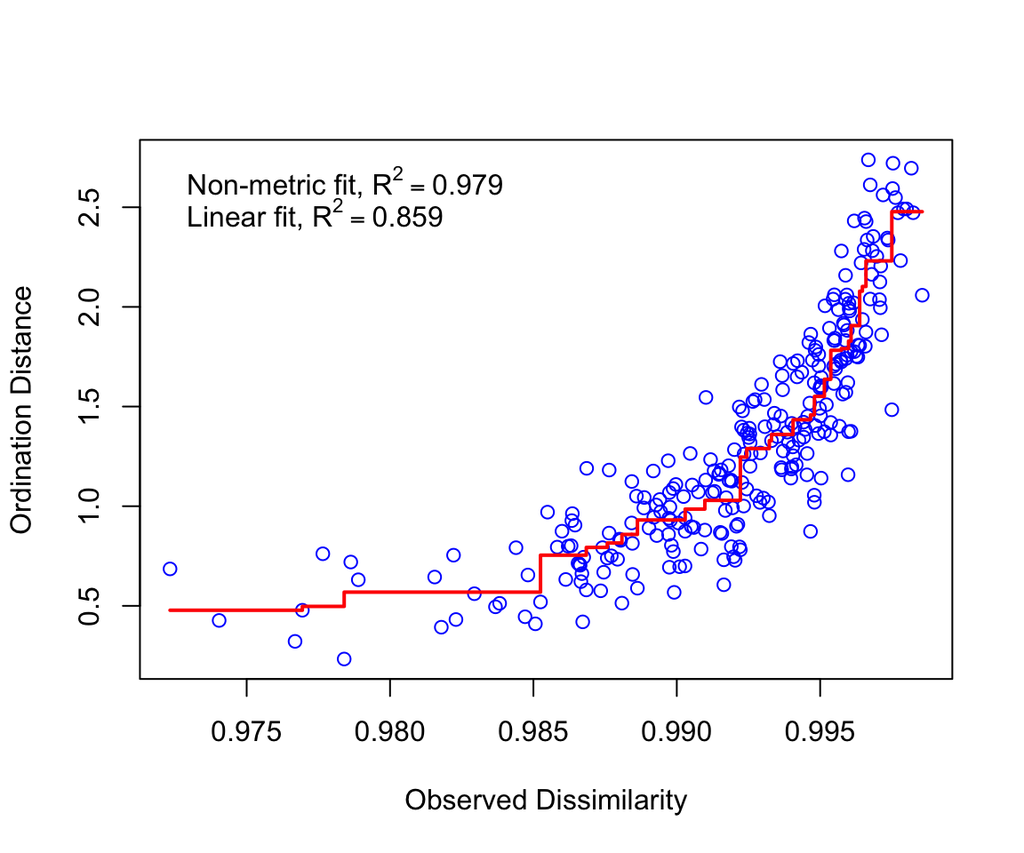

```r
stressplot(ord1)
```

```r
# Data for plotting
bact.NMDS.data<-new.env
bact.NMDS.data$NMDS1<-ord1$points[ ,1]
bact.NMDS.data$NMDS2<-ord1$points[ ,2]

# R2 Superscript for plot
bact.ss<-0.859
bact.ss<-paste("R^2 == ", round(bact.ss,2))
```

```r
# NMDS Ordination for Fungi
ord2<-metaMDS(fungi, trymax=1000, k=3)
```

```
## Square root transformation
## Wisconsin double standardization
## ... procrustes: rmse 0.0928839  max resid 0.3034965
## ... procrustes: rmse 0.08830597  max resid 0.2860047
## ... procrustes: rmse 0.003575868  max resid 0.01072803
## ... procrustes: rmse 0.08961962  max resid 0.3060466
## ... procrustes: rmse 0.01650791  max resid 0.05338204
## ... procrustes: rmse 0.0007152555  max resid 0.001363414
## *** Solution reached
```

```r
ord2
```

```
##
## Call:
## metaMDS(comm = fungi, k = 3, trymax = 1000)
##
## global Multidimensional Scaling using monoMDS
##
## Data:     wisconsin(sqrt(fungi))
## Distance: bray
##
## Dimensions: 3
## Stress:     0.1293632
## Stress type 1, weak ties
## Two convergent solutions found after 39 tries
## Scaling: centring, PC rotation
## Species: expanded scores based on 'wisconsin(sqrt(fungi))'
```

```r
scores(ord2)
```

```
##                   NMDS1        NMDS2        NMDS3
## Total_A_1  -0.348944529  0.186280313  0.135934742
## Total_A_2  -0.286004052  0.076451150  0.002441971
## Total_A_3  -0.412515511  0.387516513 -0.157515306
## Total_B_1   0.204653154  0.393310685  0.385680719
## Total_B_2   0.523932647  0.118673780  0.051392448
## Total_B_3   0.355972797  0.355107105 -0.360117387
## Total_C_1  -0.051052222  0.191997073  0.087496229
## Total_C_2   0.058152946  0.005664659  0.035151739
## Total_C_3   0.012629433  0.104521731  0.177460568
## Total_D_1   0.027629704 -0.042633798 -0.078566824
## Total_D_2   0.016487100 -0.034524146  0.010070273
## Total_D_3  -0.003218511  0.011591082 -0.012254627
## Active_A_1 -0.268447088 -0.086249162 -0.108068670
## Active_A_2 -0.325666537 -0.199312606 -0.051635789
## Active_A_3 -0.209140556  0.018353425 -0.233331949
## Active_B_1  0.157686766 -0.220598707 -0.030207306
## Active_B_2  0.302213778 -0.168164660 -0.154288554
## Active_B_3  0.215513025 -0.045309953 -0.237661757
## Active_C_1 -0.113256625 -0.106780151  0.088816736
## Active_C_2  0.139975069 -0.103025676  0.148034421
## Active_C_3  0.010703025 -0.203705967  0.341624887
## Active_D_1 -0.014153565 -0.192660306 -0.113683414
## Active_D_2 -0.011024450 -0.293853794  0.055894372
## Active_D_3  0.017874203 -0.152648592  0.017332478
```

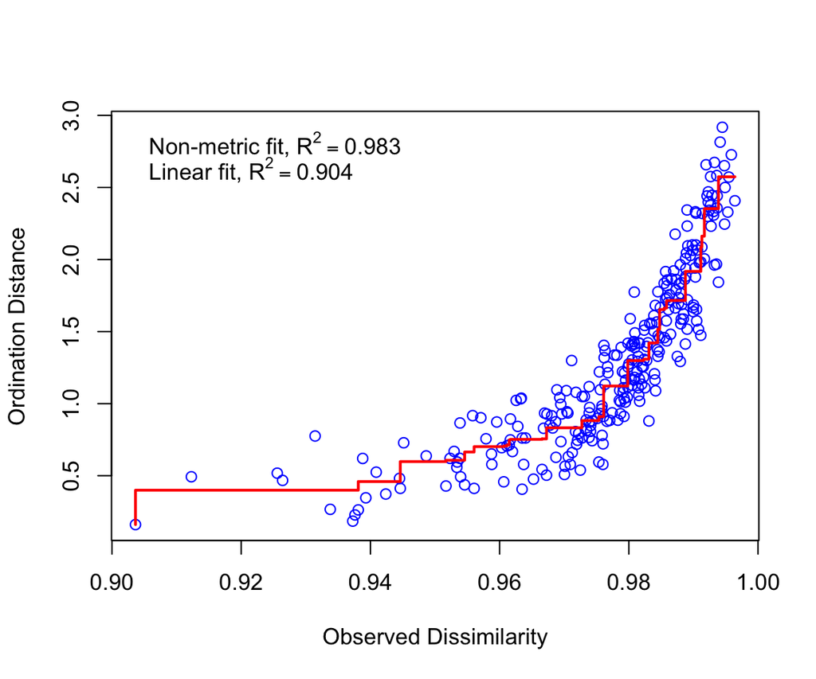

```r
stressplot(ord2)
```

```r
# Data for plotting
fungi.NMDS.data<-new.env
fungi.NMDS.data$NMDS1<-ord2$points[ ,1]
fungi.NMDS.data$NMDS2<-ord2$points[ ,2]

# R2 Superscript
fung.ss<-0.904
fung.ss<-paste("R^2 == ", round(fung.ss,2))
```

### Reproducing Figure 1 - NMDS

```r
# Set geom_point shape to new default prior to plotting
update_geom_defaults("point", list(shape=21))

# Plotting bacteria NMDS in ggplot2
bact.ggplot<-ggplot(bact.NMDS.data, aes(x=NMDS1, y=NMDS2)) + aes(shape=factor(Site)) + geom_point(colour="black", size=3.5, aes(fill=factor(Community))) + scale_fill_manual(values=c("white", "black")) + scale_shape_manual("Site", values=c(21,22,23,24))+ scale_colour_manual(values=c("black", "black")) + labs(fill="Community") + theme_bw() + scale_x_continuous(limits=c(-0.5, 0.5)) + scale_y_continuous(limits=c(-0.55, 0.45)) + annotate("text", x=-0.48, y=0.45, label = "(a)", size=6) + theme(legend.key=element_blank()) + annotate("text", x=-0.5, y=-0.50, label=bact.ss, parse=TRUE, hjust=0, size=4) + annotate("text", x=-0.5, y=-0.55, label="Stress=0.14", hjust=0, size=4) + theme(axis.ticks.y = element_blank(), axis.ticks.x = element_blank(), panel.background = element_blank(), panel.grid.major = element_blank(), panel.grid.minor = element_blank())

# Plotting fungi NMDS in ggplot2
fungi.ggplot<-ggplot(fungi.NMDS.data, aes(x=NMDS1, y=NMDS2)) + aes(shape=factor(Site)) + geom_point(colour="black", size=3.5, aes(fill=factor(Community))) + scale_fill_manual(values=c("white", "black")) + scale_shape_manual("Site", values=c(21,22,23,24)) + scale_colour_manual(values=c("black", "black")) + labs(fill="Community") + theme_bw() + scale_x_continuous(limits=c(-0.6, 0.6)) + scale_y_continuous(limits=c(-0.55, 0.45)) + annotate("text", x=-0.58, y=0.45, label = "(b)", size=6) + theme(legend.key=element_blank()) + annotate("text", x=-0.6, y=-0.5, label=fung.ss, parse=TRUE, hjust=0, size=4) + annotate("text", x=-0.6, y=-0.55, label="Stress=0.13", hjust=0, size=4) + theme(axis.ticks.y = element_blank(), axis.ticks.x = element_blank(), panel.background = element_blank(), panel.grid.major = element_blank(), panel.grid.minor = element_blank())
```

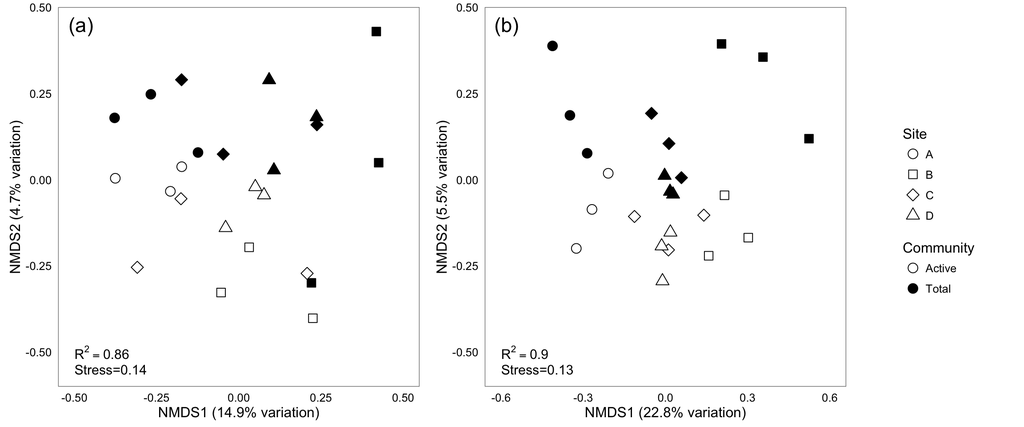

```r
# Arrange ggplot2 graphs with a specific width
grid.arrange(bact.ggplot2, fungi.ggplot2, legend, ncol=3, widths=c(5,5,2))
```

**Figure 1.** Nonmetric multidimensional scaling (NMDS) ordinations based on Bray-Curtis dissimilarity of OTU abundance between (a) bacterial and (b) fungal communities reveals spatial variation by site and between total and active communities. Each marker represents an individual plot in the NMDS charts.

### Taxonomy - Bacterial Community Relative Abundance - Order-Level

```r
# Call in bacteria taxonomy table (absolute abundance)
bact.tax<-read.table("c.g.DNA.16S.combined.trim.unique.good.filter.unique.precluster.pick.pick.an.unique_list.0.03.subsample.0.03.cons.tax.summary", header = TRUE, sep = "\t")

# Subset taxonomy file to pull out only order level taxa ("taxlevel" = 4)
bact.order<-subset(bact.tax, taxlevel==4)

# Remove N-deposition plots
bact.order<-bact.order[, -c(4:5,9:11,15:17,21:23,27:29,33:35,39:41,45:47,51:54)]

# Create new column with rankID and taxon
bact.order$taxID<-paste(bact.order$taxon,bact.order$rankID,sep="_")

# Preserve taxID as row names
row.names(bact.order)<-bact.order$taxID

# Remove non-numeric columns
bact.order.new<-bact.order[,-c(1:3,28)]

# Convert from absolute to relative abundance
bact.order.sums<-colSums(bact.order.new)
bact.order.test1<-as.matrix(bact.order.new)
bact.order.test2<-1/bact.order.sums
bact.order.test3<-t(bact.order.test1)
bact.order.test4<-(bact.order.test3*bact.order.test2)*100
bact.order.test5<-t(bact.order.test4)
bact.order.rel<-as.data.frame(bact.order.test5)
bact.order.rel$taxID<-row.names(bact.order.rel)

# Add factor columns back in
bact.order.factor<-bact.order[,c(1:3,28)]

# Merge factors back into Rel Abund table
bact.order.final<-merge(bact.order.factor,bact.order.rel,by="taxID",all=TRUE)

# Remove certain factors for downstream processing
bact.order.final<-bact.order.final[,-c(2:3)]
```

#### Separate Active Bacteria

```r
# Active data frame
bact.order.active<-bact.order.final[,1:14]

# Calculate taxon means and add new means column
bact.order.active$MEANS_Active<-rowMeans(bact.order.active[,3:14])

# Calculate taxon sd and add new sd column
bact.order.active$SD_Active<-apply(as.matrix(bact.order.active[,3:14]),1,sd)

# Preserve taxID as row names
row.names(bact.order.active)<-bact.order.active$taxID

# Remove non-numeric columns
bact.order.active.new<-bact.order.active[,-1]

# Collect all taxon greater than 1% rel abund
bact.order.active.relevant<-subset(bact.order.active.new, MEANS_Active>=1 | taxon=="Flavobacteriales")

bact.order.active.relevant<-subset(bact.order.active.relevant, taxon!="unclassified")

#Remove taxon column
bact.order.active.relevant<-bact.order.active.relevant[,-1]

# Collect all taxon less than 1% rel abund
bact.order.active.other<-subset(bact.order.active.new, MEANS_Active<1 | taxon=="unclassified")

bact.order.active.other<-subset(bact.order.active.other, taxon!="Flavobacteriales")

# Sum "unclassfied" into single row
bact.order.active.other<-ddply(bact.order.active.other, "taxon", numcolwise(sum))

# Pull "unclassified" from "other" table
bact.order.active.other.noclass<-subset(bact.order.active.other, taxon!="unclassified")

# Create "unclassified" factor to pull out these taxa from "other" table
bact.active.unclass<-"unclassified"
bact.order.active.other.unclass<-bact.order.active.other[bact.order.active.other$taxon %in% bact.active.unclass,]

# Preserve taxon as row names
row.names(bact.order.active.other.noclass)<-bact.order.active.other.noclass$taxon
row.names(bact.order.active.other.unclass)<-bact.order.active.other.unclass$taxon

# Save names of all taxa placed in "Other" category
bact.other.names<-row.names(bact.order.active.other.noclass)

#Remove taxon column
bact.order.active.other.noclass<-bact.order.active.other.noclass[,-1]
bact.order.active.other.unclass<-bact.order.active.other.unclass[,-1]

# Column sums
bact.order.active.other.vec<-colSums(bact.order.active.other.noclass)

# Bind "Other" to relevant data frame
bact.order.active.final<-rbind(bact.order.active.relevant,bact.order.active.other.vec,bact.order.active.other.unclass)

# Rename row names with "Other" column
row.names(bact.order.active.final)<-c("Acidobacteria_Gp1","Actinomycetales","Burkholderiales","Caulobacterales","Flavobacteriales","Planctomycetales","Pseudomonadales","Rhizobiales","Rhodospirillales","Sphingobacteriales","Sphingomonadales","Other","Unclassified")

# Add back in Taxon column
bact.order.active.final$Taxon<-row.names(bact.order.active.final)
```

#### Separate Total Bacteria

```r
# Total data frame
bact.order.total<-bact.order.final[,c(1:2,15:26)]

# Calculate taxon means and add new means column
bact.order.total$MEANS_Total<-rowMeans(bact.order.total[,3:14])

# Calculate taxon sd and add new sd column
bact.order.total$SD_Total<-apply(as.matrix(bact.order.total[,3:14]),1,sd)

# Preserve taxID as row names
row.names(bact.order.total)<-bact.order.total$taxID

# Remove non-numeric columns
bact.order.total.new<-bact.order.total[,-1]

# Collect all taxon greater than 1% rel abund
bact.order.total.relevant<-subset(bact.order.total.new, MEANS_Total>=1)

# Remove unclassified taxa
bact.order.total.relevant<-subset(bact.order.total.relevant, taxon!="unclassified")

# Remove TM7 taxa
bact.order.total.relevant<-subset(bact.order.total.relevant, taxon!="TM7_order_incertae_sedis")

# Remove taxon column
bact.order.total.relevant<-bact.order.total.relevant[,-1]

# Collect all taxon less than 1% rel abund including all unclassified and TM7
bact.order.total.other<-subset(bact.order.total.new, MEANS_Total<1 | taxon=="unclassified" | taxon=="TM7_order_incertae_sedis")

# Sum "unclassfied" into single row
bact.order.total.other<-ddply(bact.order.total.other, "taxon", numcolwise(sum))

# Pull "unclassified" from "other" table
bact.order.total.other.noclass<-subset(bact.order.total.other, taxon!="unclassified")

# Create "unclassified" object to pull these taxa out of "other" table
bact.total.unclass<-"unclassified"
bact.order.total.other.unclass<-bact.order.total.other[bact.order.total.other$taxon %in% bact.total.unclass,]

# Preserve taxon as row names
row.names(bact.order.total.other.noclass)<-bact.order.total.other.noclass$taxon
row.names(bact.order.total.other.unclass)<-bact.order.total.other.unclass$taxon

#Remove taxon column
bact.order.total.other.noclass<-bact.order.total.other.noclass[,-1]
bact.order.total.other.unclass<-bact.order.total.other.unclass[,-1]

# Column sums
bact.order.total.other.vec<-colSums(bact.order.total.other.noclass)

# Bind "Other" to relevant data frame
bact.order.total.final<-rbind(bact.order.total.relevant,bact.order.total.other.vec,bact.order.total.other.unclass)

# Rename row names with "Other" column
row.names(bact.order.total.final)<-c("Acidobacteria_Gp1","Actinomycetales","Burkholderiales","Caulobacterales","Flavobacteriales","Planctomycetales","Pseudomonadales","Rhizobiales","Rhodospirillales","Sphingobacteriales","Sphingomonadales","Other","Unclassified")

# Add back in Taxon column
bact.order.total.final$Taxon<-row.names(bact.order.total.final)

# Merge Active and Total data frames
bact.order.merge<-merge(bact.order.total.final,bact.order.active.final,by="Taxon",all=TRUE)
```

### MANOVA on change in relative abundance between bacterial communities at the order-level

```r
# Final Bacteria Taxonomy table for MANOVA
bact.tax.final<-bact.order.merge[, -c(14,15,28,29)]

### Transpose taxonomy table

# Remember taxon as non-numeric values
bact.tax.final.taxon<-bact.tax.final$Taxon

# Transpose all but first column (Taxon)
bact.tax.final<-as.data.frame(t(bact.tax.final[,-1]))
colnames(bact.tax.final)<-bact.tax.final.taxon

# Add new columns for "Site" and "Community" to the end of the data table
bact.tax.final$Site <- c("A","A","A","B","B","B","C","C","C","D","D","D","A","A","A","B","B","B","C","C","C","D","D","D")

bact.tax.final$Community <- c("Total","Total","Total","Total","Total","Total","Total","Total","Total","Total","Total","Total","Active","Active","Active","Active","Active","Active","Active","Active","Active","Active","Active","Active")

#Rename "Acidobacteria Gp1" without spaces
names(bact.tax.final)[names(bact.tax.final)=='Acidobacteria Gp1']<-'Acidobacteria_Gp1'

#Create matrix of numeric columns
bact.bind.mat<-as.matrix(cbind(bact.tax.final[,1:13]))

# MANOVA
bact.manova<-manova(bact.bind.mat~Community, data=bact.tax.final)
bact.man.sum<-summary.aov(bact.manova)
bact.man.sum
```

```
##  Response Acidobacteria_Gp1 :
##             Df  Sum Sq Mean Sq F value Pr(>F)
## Community    1   58.45  58.448  0.9802 0.3329
## Residuals   22 1311.79  59.627
##
##  Response Actinomycetales :
##             Df Sum Sq Mean Sq F value Pr(>F)
## Community    1  12.57  12.568  0.6624 0.4244
## Residuals   22 417.43  18.974
##
##  Response Burkholderiales :
##             Df  Sum Sq Mean Sq F value  Pr(>F)
## Community    1  16.655 16.6551    3.26 0.08469 .
## Residuals   22 112.395  5.1089
## ---
## Signif. codes:  0 '***' 0.001 '**' 0.01 '*' 0.05 '.' 0.1 ' ' 1
##
##  Response Caulobacterales :
##             Df Sum Sq Mean Sq F value  Pr(>F)
## Community    1 17.301 17.3009  4.7434 0.04041 *
## Residuals   22 80.242  3.6474
## ---
## Signif. codes:  0 '***' 0.001 '**' 0.01 '*' 0.05 '.' 0.1 ' ' 1
##
##  Response Flavobacteriales :
##             Df  Sum Sq Mean Sq F value Pr(>F)
## Community    1  0.0572 0.05716  0.0582 0.8116
## Residuals   22 21.6129 0.98241
##
##  Response Other :
##             Df Sum Sq Mean Sq F value Pr(>F)
## Community    1  0.625 0.62503  0.2161 0.6466
## Residuals   22 63.623 2.89193
##
##  Response Planctomycetales :
##             Df  Sum Sq Mean Sq F value  Pr(>F)
## Community    1  23.836 23.8360  4.4975 0.04545 *
## Residuals   22 116.596  5.2998
## ---
## Signif. codes:  0 '***' 0.001 '**' 0.01 '*' 0.05 '.' 0.1 ' ' 1
```

[output cut: 23 more lines]

```
##             Df Sum Sq Mean Sq F value Pr(>F)
## Community    1 18.858 18.8584  5.3614 0.0303 *
## Residuals   22 77.383  3.5174
## ---
## Signif. codes:  0 '***' 0.001 '**' 0.01 '*' 0.05 '.' 0.1 ' ' 1
##
##  Response Sphingomonadales :
##             Df Sum Sq Mean Sq F value Pr(>F)
## Community    1  0.102 0.10179   0.066 0.7997
## Residuals   22 33.956 1.54345
##
##  Response Unclassified :
##             Df  Sum Sq Mean Sq F value Pr(>F)
## Community    1   3.775  3.7755  0.4254  0.521
## Residuals   22 195.255  8.8752
```

```r
# Extract p-values
bact.man.p<-lapply(bact.man.sum, function(i) {
  i[1,5]
})

# Make into df
bact.man.p.df<-as.data.frame(do.call(rbind,bact.man.p))

# Clean up the format of df
colnames(bact.man.p.df)<-"P-Value"

# Get rid of "Response"
bact.man.p.df$ID<-row.names(bact.man.p.df)

bact.man.p.df$Taxon<-gsub(" Response ","",bact.man.p.df$ID)

# Make Taxon row names
row.names(bact.man.p.df)<-bact.man.p.df$Taxon

# Remove ID and Taxon columns
bact.man.p.df<-subset(bact.man.p.df,select="P-Value")
```

### SIMPER Analysis for Taxon Contributions to Dissimilarity

```r
#Preserve Taxon as row names
bact.order.simper<-bact.order.merge

# Remove non-numeric column and Means and SD columns
bact.order.simper<-bact.order.simper[,-c(14,15,28,29)]

### Transpose taxonomy table

# Remember taxon as non-numeric values
bact.order.simper.taxon<-bact.order.simper$Taxon

# Transpose all but first column (Taxon)
bact.order.simper<-as.data.frame(t(bact.order.simper[,-1]))
colnames(bact.order.simper)<-bact.order.simper.taxon

# Run SIMPER Analysis
bact.sim<-with(new.env, simper(bact.order.simper, Community))
summary(bact.sim)
```

```
##
## Contrast: Total_Active
##
##                     average       sd  ratio    ava     avb cumsum
## Acidobacteria_Gp1  0.041907 0.035054 1.1955 13.635 10.5139 0.2072
## Actinomycetales    0.025614 0.016364 1.5653 21.544 20.0965 0.3338
## Rhizobiales        0.019272 0.012033 1.6016 13.907 11.2809 0.4290
## Planctomycetales   0.015487 0.010154 1.5252  3.742  5.7348 0.5056
## Rhodospirillales   0.014239 0.010672 1.3342  4.061  5.7171 0.5760
## Unclassified       0.014088 0.015020 0.9380 13.250 12.4565 0.6456
## Pseudomonadales    0.013797 0.017848 0.7731  1.345  3.8478 0.7138
## Burkholderiales    0.013634 0.010885 1.2525  5.098  6.7644 0.7812
## Caulobacterales    0.011434 0.010454 1.0938  4.847  3.1492 0.8377
## Sphingobacteriales 0.011325 0.010598 1.0687  8.033  9.8060 0.8937
## Other              0.009629 0.006538 1.4728  5.424  5.7469 0.9413
## Sphingomonadales   0.006811 0.004995 1.3636  4.045  3.9152 0.9750
## Flavobacteriales   0.005064 0.004446 1.1390  1.068  0.9708 1.0000
## Permutation: free
## Number of permutations: 0
```

```r
# Convert to Dataframe
bact.sim.df<-data.frame(bact.sim$Total_Active$species,bact.sim$Total_Active$average,bact.sim$Total_Active$ava,bact.sim$Total_Active$avb, stringsAsFactors = FALSE)

# Calculate overall % Dissimilarity between Total and Active communities
sum(bact.sim.df$bact.sim.Total_Active.average)*100
```

```
## [1] 20.23007
```

```r
# Set Overall contribution values aside
bact.sim.overall<-bact.sim$Total_Active$overall

# Calculate taxon contributions to dissimilarity
bact.sim.df$Contribution<-(bact.sim.df$bact.sim.Total_Active.average/bact.sim.overall)*100

# Pull out relevant columns
bact.sim.final<-subset(bact.sim.df,select = c("bact.sim.Total_Active.species","Contribution"))

# Rename column 1 to Taxon
colnames(bact.sim.final)<-c("Taxon","SIMPER")
```

```r
# Final Bacteria Means table (Table 3 recreated)
bact.tax.final.means<-subset(bact.order.merge, select=c("Taxon","MEANS_Total","SD_Total","MEANS_Active","SD_Active"))

# Add in SIMPER Contribution column to final table
bact.tax.final.means<-merge(bact.tax.final.means,bact.sim.final,by="Taxon",all=TRUE)

# Sort in decending order from Total community
bact.tax.final.means<-bact.tax.final.means[order(bact.tax.final.means$MEANS_Total,decreasing = TRUE),]

# Round numbers in each column
bact.tax.final.means$MEANS_Total<-round(bact.tax.final.means$MEANS_Total,0)

bact.tax.final.means$MEANS_Active<-round(bact.tax.final.means$MEANS_Active,0)

bact.tax.final.means$SD_Total<-round(bact.tax.final.means$SD_Total,1)

bact.tax.final.means$SD_Active<-round(bact.tax.final.means$SD_Active,1)

# Calculate difference between Total and Active Means
bact.tax.final.means$Difference<-bact.tax.final.means$MEANS_Active - bact.tax.final.means$MEANS_Total

bact.tax.final.means$Difference<-round(bact.tax.final.means$Difference,0)

# Preserve taxon as row names
row.names(bact.tax.final.means)<-bact.tax.final.means$Taxon
bact.tax.final.means<-bact.tax.final.means[,-1]

# Paste Total means with sd into single column
bact.tax.final.means$Total<-paste(bact.tax.final.means$MEANS_Total,"±",bact.tax.final.means$SD_Total,sep=" ")

# Paste Active means with sd into single column
bact.tax.final.means$Active<-paste(bact.tax.final.means$MEANS_Active,"±",bact.tax.final.means$SD_Active,sep=" ")

# Subset out columns of interest
bact.table2<-subset(bact.tax.final.means,select=c("Total","Active","Difference","SIMPER"))

# Round SIMPER values
bact.table2$SIMPER<-round(bact.table2$SIMPER,0)

# Merging everything into Table 3
bact.table2$Taxon<-row.names(bact.table2)
bact.man.p.df$Taxon<-row.names(bact.man.p.df)

#Final table
bact.table2.final<-merge(bact.table2,bact.man.p.df,by="Taxon",all=TRUE)

# Round p-values to 2 decimals
bact.table2.final$`P-Value`<-round(bact.table2.final$`P-Value`,3)

# Put P-values in parantheses
bact.table2.final$P2<-paste("(",bact.table2.final$`P-Value`,")",sep="")

# Add + signs to Difference factors
for(i in 1:length(bact.table2.final$Taxon)) {
  if (bact.table2.final[i,4]>0) {
    bact.table2.final[i,4]<-paste("+",bact.table2.final[i,4],sep="")}
}

# Combine Difference with P-values in single column
bact.table2.final$`Difference % (P-Value)`<-paste(bact.table2.final$Difference,bact.table2.final$P2,sep=" ")

# Remove unnecessary columns from final table
bact.table2.final<-bact.table2.final[,-c(4,6,7)]

bact.table2.final<-bact.table2.final[c("Taxon","Total","Active","Difference % (P-Value)","SIMPER")]

# Reorder Taxon by Total Rel Abund
bact.table2.final$Taxon<-as.factor(bact.table2.final$Taxon)
bact.table2.final$Taxon<-reorder(bact.table2.final$Taxon,c(3,1,5,6,10,13,7,11,2,8,4,9,12))
bact.table2.final<-bact.table2.final[order(bact.table2.final$Taxon),]

# Name Taxon row name
row.names(bact.table2.final)<-bact.table2.final$Taxon

# Remove Taxon column
bact.table2.final<-bact.table2.final[,-1]

# Rename rows in the data frame to environmental variables
row.names(bact.table2.final)<-c("Actinomycetales","Rhizobiales","Acidobacteria Gp1","Sphingobacteriales","Burkholderiales","Caulobacterales","Planctomycetales","Rhodospirillales","Sphingomonadales","Flavobacteriales","Pseudomonadales","Unclassified","Other")

# Rename columns
colnames(bact.table2.final)<-c("% Total","% Active", "% Difference (P-value)","% Dissimilarity Contribution")

# Set pander options (table formatting)
set.alignment('right',row.names = 'left')
pander(bact.table2.final,caption = "Table 4. Relative abundance of total and active bacterial taxa (mean ± standard deviation) with mean percent difference from total community.")
```

|  | % Total | % Active | % Difference (P-value) | % Dissimilarity Contribution |
| --- | --- | --- | --- | --- |
| **Actinomycetales** | 22 ± 5.5 | 20 ± 2.8 | -2 (0.424) | 13 |
| **Rhizobiales** | 14 ± 3.6 | 11 ± 1.5 | -3 (0.028) | 10 |
| **Acidobacteria Gp1** | 14 ± 8.8 | 11 ± 6.5 | -3 (0.333) | 21 |
| **Sphingobacteriales** | 8 ± 1.2 | 10 ± 2.4 | +2 (0.03) | 6 |
| **Burkholderiales** | 5 ± 1.6 | 7 ± 2.7 | +2 (0.085) | 7 |
| **Caulobacterales** | 5 ± 2.4 | 3 ± 1.3 | -2 (0.04) | 6 |
| **Planctomycetales** | 4 ± 2.5 | 6 ± 2.1 | +2 (0.045) | 8 |
| **Rhodospirillales** | 4 ± 2.1 | 6 ± 2.5 | +2 (0.095) | 7 |
| **Sphingomonadales** | 4 ± 1.2 | 4 ± 1.3 | 0 (0.8) | 3 |
| **Flavobacteriales** | 1 ± 0.9 | 1 ± 1.1 | 0 (0.812) | 3 |
| **Pseudomonadales** | 1 ± 1 | 4 ± 3.8 | +3 (0.037) | 7 |
| **Unclassified** | 13 ± 5.1 | 12 ± 4.4 | -1 (0.521) | 7 |
| **Other** | 5 ± 4 | 6 ± 4 | +1 (0.647) | 5 |

**Supplemental Table S3.** List of “Other” bacteria (<1% relative abundance)

```r
bact.other.names
```

```
##  [1] "Acidimicrobiales"
##  [2] "Acidobacteria_Gp10_order_incertae_sedis"
##  [3] "Acidobacteria_Gp16_order_incertae_sedis"
##  [4] "Acidobacteria_Gp2_order_incertae_sedis"
##  [5] "Acidobacteria_Gp3_order_incertae_sedis"
##  [6] "Acidobacteria_Gp3_order_incetae_sedis"
##  [7] "Acidobacteria_Gp4_order_incertae_sedis"
##  [8] "Acidobacteria_Gp5_order_incertae_sedis"
##  [9] "Acidobacteria_Gp6_order_incertae_sedis"
## [10] "Acidobacteria_Gp7_order_incertae_sedis"
## [11] "Alphaproteobacteria_order_incertae_sedis"
## [12] "Alteromonadales"
## [13] "Anaerolineales"
## [14] "Armatimonadales"
## [15] "Armatimonadetes_gp4_order_incetae_sedis"
```

[output cut: 42 more lines]

### Taxonomy - Fungal Community Relative Abundance

```r
# Call in fungal taxonomy table (absolute abundance)
fungi.tax<-read.table("c.g.DNA.28S.combined.trim.unique.good.filter.unique.precluster.pick.pick.an.unique_list.0.01.subsample.0.01.cons.tax.summary", header = TRUE, sep = "\t")

# Subset taxonomy file to pull out only class level taxa ("taxlevel" = 4)
fungi.phyla<-subset(fungi.tax, taxlevel==4)

# Remove N-deposition plot columns
fungi.phyla<-fungi.phyla[, -c(4:5,9:11,15:17,21:23,27:29,33:35,39:41,45:47,51:54)]

# Create new column with rankID and taxon
fungi.phyla$taxID<-paste(fungi.phyla$taxon,fungi.phyla$rankID,sep="_")

# Preserve taxID as row names
row.names(fungi.phyla)<-fungi.phyla$taxID

# Remove non-numeric columns
fungi.phyla.new<-fungi.phyla[,-c(1:3,28)]

# Convert from absolute to relative abundance
fungi.sums<-colSums(fungi.phyla.new)
fungi.test1<-as.matrix(fungi.phyla.new)
fungi.test2<-1/fungi.sums
fungi.test3<-t(fungi.test1)
fungi.test4<-(fungi.test3*fungi.test2)*100
fungi.test5<-t(fungi.test4)
fungi.phyla.rel<-as.data.frame(fungi.test5)
fungi.phyla.rel$taxID<-row.names(fungi.phyla.rel)

# Add factor columns back in
fungi.phyla.factor<-fungi.phyla[,c(1:3,28)]

# Merge factors back into Rel Abund table
fungi.phyla.final<-merge(fungi.phyla.factor,fungi.phyla.rel,by="taxID",all=TRUE)

# Remove certain factors for downstream processing
fungi.phyla.final<-fungi.phyla.final[,-c(2:3)]
```

#### Subset Active Fungi

```r
# Active data frame
fungi.active<-fungi.phyla.final[,1:14]

# Calculate taxon means and add new means column
fungi.active$MEANS_Active<-rowMeans(fungi.active[,3:14])

# Calculate taxon sd and add new sd column
fungi.active$SD_Active<-apply(as.matrix(fungi.active[,3:14]),1,sd)

# Preserve taxID as row names
row.names(fungi.active)<-fungi.active$taxID

# Remove non-numeric columns
fungi.active.new<-fungi.active[,-1]

# Collect all taxon greater than 1% rel abund
fungi.active.relevant<-subset(fungi.active.new, MEANS_Active>=1)

fungi.active.relevant<-subset(fungi.active.relevant, taxon!="unclassified")

#Remove taxon column
fungi.active.relevant<-fungi.active.relevant[,-1]

# Collect all taxon less than 1% rel abund
fungi.active.other<-subset(fungi.active.new, MEANS_Active<1 | taxon=="unclassified")

# Sum "unclassfied" into single row
fungi.active.other<-ddply(fungi.active.other, "taxon", numcolwise(sum))

# Pull "unclassified" from "other" table
fungi.active.other.noclass<-subset(fungi.active.other, taxon!="unclassified")

# Create "unclassified" factor to pull out these taxa from "other" table
fungi.active.unclass<-"unclassified"
fungi.active.other.unclass<-fungi.active.other[fungi.active.other$taxon %in% fungi.active.unclass,]

# Preserve taxon as row names
row.names(fungi.active.other.noclass)<-fungi.active.other.noclass$taxon
row.names(fungi.active.other.unclass)<-fungi.active.other.unclass$taxon

# Save names of all taxa placed in "Other" category
fungi.other.names<-row.names(fungi.active.other.noclass)

#Remove taxon column
fungi.active.other.noclass<-fungi.active.other.noclass[,-1]
fungi.active.other.unclass<-fungi.active.other.unclass[,-1]

# Column sums
fungi.active.other.vec<-colSums(fungi.active.other.noclass)

# Bind "Other" and "unclassified" to relevant data frame
fungi.active.final<-rbind(fungi.active.relevant,fungi.active.other.vec,fungi.active.other.unclass)

# Rename row names with "Other" column
row.names(fungi.active.final)<-c("Agaricomycetes","Dothideomycetes","Eurotiomycetes","Leotiomycetes","Microbotryomycetes","Sordariomycetes","Tremellomycetes","Other","Unclassified")

# Add back in Taxon column
fungi.active.final$Taxon<-row.names(fungi.active.final)
```

#### Separate Total Fungi

```r
# Total data frame
fungi.total<-fungi.phyla.final[,c(1:2,15:26)]

# Calculate taxon means and add new means column
fungi.total$MEANS_Total<-rowMeans(fungi.total[,3:14])

# Calculate taxon sd and add new sd column
fungi.total$SD_Total<-apply(as.matrix(fungi.total[,3:14]),1,sd)

# Preserve taxID as row names
row.names(fungi.total)<-fungi.total$taxID

# Remove non-numeric columns
fungi.total.new<-fungi.total[,-1]

# Collect all taxon greater than 1% rel abund
fungi.total.relevant<-subset(fungi.total.new, MEANS_Total>=1)

fungi.total.relevant<-subset(fungi.total.relevant, taxon!="unclassified")

#Remove taxon column
fungi.total.relevant<-fungi.total.relevant[,-1]

# Collect all taxon less than 1% rel abund
fungi.total.other<-subset(fungi.total.new, MEANS_Total<1 | taxon=="unclassified")

# Sum "unclassfied" into single row
fungi.total.other<-ddply(fungi.total.other, "taxon", numcolwise(sum))

# Pull "unclassified" from "other" table
fungi.total.other.noclass<-subset(fungi.total.other, taxon!="unclassified")

# Create "unclassified" factor to pull out these taxa from "other" table
fungi.total.unclass<-"unclassified"
fungi.total.other.unclass<-fungi.total.other[fungi.total.other$taxon %in% fungi.total.unclass,]

# Preserve taxon as row names
row.names(fungi.total.other.noclass)<-fungi.total.other.noclass$taxon
row.names(fungi.total.other.unclass)<-fungi.total.other.unclass$taxon

#Remove taxon column
fungi.total.other.noclass<-fungi.total.other.noclass[,-1]
fungi.total.other.unclass<-fungi.total.other.unclass[,-1]

# Column sums
fungi.total.other.vec<-colSums(fungi.total.other.noclass)

# Bind "Other" and "unclassified" to relevant data frame
fungi.total.final<-rbind(fungi.total.relevant,fungi.total.other.vec,fungi.total.other.unclass)

# Rename row names with "Other" column
row.names(fungi.total.final)<-c("Agaricomycetes","Dothideomycetes","Eurotiomycetes","Leotiomycetes","Microbotryomycetes","Sordariomycetes","Tremellomycetes","Other","Unclassified")

# Add back in Taxon column
fungi.total.final$Taxon<-row.names(fungi.total.final)

# Merge Active and Total data frames
fungi.merge<-merge(fungi.total.final,fungi.active.final,by="Taxon",all=TRUE)
```

### MANOVA on change in relative abundance between fungal communities at the class-level

```r
# Final Fungal taxonomy table for MANOVA
fungi.tax.final<-fungi.merge[, -c(14,15,28,29)]

### Transpose taxonomy table

# Remember taxon as non-numeric values
fungi.tax.final.taxon<-fungi.tax.final$Taxon

# Transpose all but first column (Taxon)
fungi.tax.final<-as.data.frame(t(fungi.tax.final[,-1]))
colnames(fungi.tax.final)<-fungi.tax.final.taxon

# Add new columns for "Site" and "Community" to the end of the data table
fungi.tax.final$Site <- c("A","A","A","B","B","B","C","C","C","D","D","D","A","A","A","B","B","B","C","C","C","D","D","D")

fungi.tax.final$Community <- c("Total","Total","Total","Total","Total","Total","Total","Total","Total","Total","Total","Total","Active","Active","Active","Active","Active","Active","Active","Active","Active","Active","Active","Active")

#Create matrix of numeric columns
fungi.bind.mat<-as.matrix(cbind(fungi.tax.final[,1:9]))

# MANOVA
fungi.manova<-manova(fungi.bind.mat~Community, data=fungi.tax.final)
fungi.man.sum<-summary.aov(fungi.manova)
fungi.man.sum
```

```
##  Response Agaricomycetes :
##             Df Sum Sq Mean Sq F value   Pr(>F)
## Community    1 295.51   295.5  11.068 0.003061 **
## Residuals   22 587.41    26.7
## ---
## Signif. codes:  0 '***' 0.001 '**' 0.01 '*' 0.05 '.' 0.1 ' ' 1
##
##  Response Dothideomycetes :
##             Df  Sum Sq Mean Sq F value   Pr(>F)
## Community    1  81.935  81.935  8.7148 0.007367 **
## Residuals   22 206.841   9.402
## ---
## Signif. codes:  0 '***' 0.001 '**' 0.01 '*' 0.05 '.' 0.1 ' ' 1
##
##  Response Eurotiomycetes :
##             Df  Sum Sq Mean Sq F value Pr(>F)
## Community    1  0.5667 0.56673  0.5564 0.4636
## Residuals   22 22.4099 1.01863
##
##  Response Leotiomycetes :
##             Df Sum Sq Mean Sq F value  Pr(>F)
## Community    1 1134.8 1134.80  6.3918 0.01915 *
## Residuals   22 3905.8  177.54
## ---
## Signif. codes:  0 '***' 0.001 '**' 0.01 '*' 0.05 '.' 0.1 ' ' 1
##
##  Response Microbotryomycetes :
##             Df Sum Sq Mean Sq F value    Pr(>F)
## Community    1 62.323  62.323  17.527 0.0003826 ***
## Residuals   22 78.229   3.556
## ---
## Signif. codes:  0 '***' 0.001 '**' 0.01 '*' 0.05 '.' 0.1 ' ' 1
##
##  Response Other :
##             Df  Sum Sq Mean Sq F value  Pr(>F)
## Community    1  3.8686  3.8686  5.6927 0.02607 *
## Residuals   22 14.9507  0.6796
## ---
## Signif. codes:  0 '***' 0.001 '**' 0.01 '*' 0.05 '.' 0.1 ' ' 1
##
##  Response Sordariomycetes :
##             Df  Sum Sq Mean Sq F value Pr(>F)
## Community    1  142.65 142.646  1.6572 0.2114
## Residuals   22 1893.66  86.075
##
##  Response Tremellomycetes :
##             Df Sum Sq Mean Sq F value     Pr(>F)
## Community    1 65.470  65.470  23.814 0.00007048 ***
## Residuals   22 60.482   2.749
## ---
## Signif. codes:  0 '***' 0.001 '**' 0.01 '*' 0.05 '.' 0.1 ' ' 1
##
##  Response Unclassified :
##             Df Sum Sq Mean Sq F value Pr(>F)
## Community    1   0.47  0.4659    0.03  0.864
## Residuals   22 341.16 15.5072
```

```r
# Extract p-values
fungi.man.p<-lapply(fungi.man.sum, function(i) {
  i[1,5]
})

# Make into df
fungi.man.p.df<-as.data.frame(do.call(rbind,fungi.man.p))

# Clean up the format of df
colnames(fungi.man.p.df)<-"P-Value"

# Get rid of "Response"
fungi.man.p.df$ID<-row.names(fungi.man.p.df)

fungi.man.p.df$Taxon<-gsub(" Response ","",fungi.man.p.df$ID)

# Make Taxon row names
row.names(fungi.man.p.df)<-fungi.man.p.df$Taxon

# Remove ID and Taxon columns
fungi.man.p.df<-subset(fungi.man.p.df,select="P-Value")
```

### SIMPER Analysis for Taxon Contributions to Dissimilarity

```r
#Preserve Taxon as row names
fungi.simper<-fungi.merge

# Remove non-numeric column and Means and SD columns
fungi.simper<-fungi.simper[,-c(14,15,28,29)]

### Transpose taxonomy table

# Remember taxon as non-numeric values
fungi.simper.taxon<-fungi.simper$Taxon

# Transpose all but first column (Taxon)
fungi.simper<-as.data.frame(t(fungi.simper[,-1]))
colnames(fungi.simper)<-fungi.simper.taxon

# Run SIMPER Analysis
fungi.sim<-with(new.env, simper(fungi.simper, Community))
summary(fungi.sim)
```

```
##
## Contrast: Total_Active
##
##                     average       sd ratio    ava    avb cumsum
## Leotiomycetes      0.095148 0.061960 1.536 45.320 31.568 0.3402
## Sordariomycetes    0.053022 0.041716 1.271 20.071 15.195 0.5298
## Agaricomycetes     0.042972 0.024752 1.736  4.932 11.950 0.6835
## Dothideomycetes    0.022337 0.016592 1.346  8.064 11.760 0.7634
## Unclassified       0.021366 0.016061 1.330 14.519 14.798 0.8398
## Microbotryomycetes 0.017116 0.011428 1.498  1.715  4.938 0.9010
## Tremellomycetes    0.016824 0.010796 1.558  3.050  6.353 0.9611
## Other              0.005471 0.004178 1.310  1.087  1.890 0.9807
## Eurotiomycetes     0.005398 0.004478 1.205  1.242  1.550 1.0000
## Permutation: free
## Number of permutations: 0
```

```r
# Convert to Dataframe
fungi.sim.df<-data.frame(fungi.sim$Total_Active$species,fungi.sim$Total_Active$average,fungi.sim$Total_Active$ava,fungi.sim$Total_Active$avb, stringsAsFactors = FALSE)

# Calculate overall % Dissimilarity between Total and Active communities
sum(fungi.sim.df$fungi.sim.Total_Active.average)*100
```

```
## [1] 27.96541
```

```r
# Set Overall contribution values aside
fungi.sim.overall<-fungi.sim$Total_Active$overall

# Calculate taxon contributions to dissimilarity
fungi.sim.df$Contribution<-(fungi.sim.df$fungi.sim.Total_Active.average/fungi.sim.overall)*100

# Pull out relevant columns
fungi.sim.final<-subset(fungi.sim.df,select = c("fungi.sim.Total_Active.species","Contribution"))

# Rename column 1 to Taxon
colnames(fungi.sim.final)<-c("Taxon","SIMPER")
```

### Recreating Table 4. Relative abundance of total and active fungi with % difference between communities and SIMPER % dissimillarity of taxa between communities.

```r
# Final Fungi Means table (Table 3 recreated)
fungi.tax.final.means<-subset(fungi.merge, select=c("Taxon","MEANS_Total","SD_Total","MEANS_Active","SD_Active"))

# Add in SIMPER Contribution column to final table
fungi.tax.final.means<-merge(fungi.tax.final.means,fungi.sim.final,by="Taxon",all=TRUE)

# Sort in decending order from Total community
fungi.tax.final.means<-fungi.tax.final.means[order(fungi.tax.final.means$MEANS_Total,decreasing = TRUE),]

# Round numbers in each column
fungi.tax.final.means$MEANS_Total<-round(fungi.tax.final.means$MEANS_Total,0)

fungi.tax.final.means$MEANS_Active<-round(fungi.tax.final.means$MEANS_Active,0)

fungi.tax.final.means$SD_Total<-round(fungi.tax.final.means$SD_Total,1)

fungi.tax.final.means$SD_Active<-round(fungi.tax.final.means$SD_Active,1)

# Calculate difference between Total and Active Means
fungi.tax.final.means$Difference<-fungi.tax.final.means$MEANS_Active - fungi.tax.final.means$MEANS_Total

fungi.tax.final.means$Difference<-round(fungi.tax.final.means$Difference,0)

# Preserve taxon as row names
row.names(fungi.tax.final.means)<-fungi.tax.final.means$Taxon
fungi.tax.final.means<-fungi.tax.final.means[,-1]

#Paste Total means with sd into single column
fungi.tax.final.means$Total<-paste(fungi.tax.final.means$MEANS_Total,"±",fungi.tax.final.means$SD_Total,sep=" ")

#Paste Active means with sd into single column
fungi.tax.final.means$Active<-paste(fungi.tax.final.means$MEANS_Active,"±",fungi.tax.final.means$SD_Active,sep=" ")

# Subset out columns of interest
fungi.table2<-subset(fungi.tax.final.means,select=c("Total","Active","Difference","SIMPER"))

# Round SIMPER values
fungi.table2$SIMPER<-round(fungi.table2$SIMPER,0)

# Merging everything into Table 2
fungi.table2$Taxon<-row.names(fungi.table2)
fungi.man.p.df$Taxon<-row.names(fungi.man.p.df)

#Final table
fungi.table2.final<-merge(fungi.table2,fungi.man.p.df,by="Taxon",all=TRUE)

# Round p-values to 2 decimals
fungi.table2.final$`P-Value`<-round(fungi.table2.final$`P-Value`,3)

# Put P-values in parantheses
fungi.table2.final$P2<-paste("(",fungi.table2.final$`P-Value`,")",sep="")

# Add + signs to Difference factors
for(i in 1:length(fungi.table2.final$Taxon)) {
  if (fungi.table2.final[i,4]>0) {
    fungi.table2.final[i,4]<-paste("+",fungi.table2.final[i,4],sep="")}
}

# Combine Difference with P-values in single column
fungi.table2.final$`Difference % (P-Value)`<-paste(fungi.table2.final$Difference,fungi.table2.final$P2,sep=" ")

# Remove unnecessary columns from final table
fungi.table2.final<-fungi.table2.final[,-c(4,6,7)]

fungi.table2.final<-fungi.table2.final[c("Taxon","Total","Active","Difference % (P-Value)","SIMPER")]

# Reorder Taxon by Total Rel Abund
fungi.table2.final$Taxon<-as.factor(fungi.table2.final$Taxon)
fungi.table2.final$Taxon<-reorder(fungi.table2.final$Taxon,c(4,3,7,1,6,9,2,5,8))
fungi.table2.final<-fungi.table2.final[order(fungi.table2.final$Taxon),]

# Name Taxon row name
row.names(fungi.table2.final)<-fungi.table2.final$Taxon

# Remove Taxon column
fungi.table2.final<-fungi.table2.final[,-1]

# Rename rows in the data frame to environmental variables
row.names(fungi.table2.final)<-c("Leotiomycetes","Sordariomycetes","Dothideomycetes","Agaricomycetes","Tremellomycetes","Microbotryomycetes","Eurotiomycetes","Unclassified","Other")

# Rename columns
colnames(fungi.table2.final)<-c("% Total","% Active", "% Difference (P-value)","% Dissimilarity Contribution")

# Set pander options (table formatting)
set.alignment('right',row.names = 'left')
pander(fungi.table2.final,caption = "Table 4. Relative abundance of total and active fungal taxa (mean ± standard deviation) with mean percent difference from total community.")
```

Table 4. Relative abundance of total and active fungal taxa (mean ± standard deviation) with mean percent difference from total community.

|  | % Total | % Active | % Difference (P-value) | % Dissimilarity Contribution |
| --- | --- | --- | --- | --- |
| **Leotiomycetes** | 45 ± 12.8 | 32 ± 13.8 | -13 (0.019) | 34 |
| **Sordariomycetes** | 20 ± 11 | 15 ± 7.1 | -5 (0.211) | 19 |
| **Dothideomycetes** | 8 ± 2.4 | 12 ± 3.6 | +4 (0.007) | 8 |
| **Agaricomycetes** | 5 ± 3.4 | 12 ± 6.5 | +7 (0.003) | 15 |
| **Tremellomycetes** | 3 ± 1.1 | 6 ± 2.1 | +3 (0) | 6 |
| **Microbotryomycetes** | 2 ± 1.1 | 5 ± 2.4 | +3 (0) | 6 |
| **Eurotiomycetes** | 1 ± 0.9 | 2 ± 1.1 | +1 (0.464) | 2 |
| **Unclassified** | 15 ± 4.8 | 15 ± 4.4 | 0 (0.864) | 8 |
| **Other** | 1 ± 1.3 | 2 ± 2.1 | +1 (0.026) | 2 |

**Supplemental Table S4.** List of “Other” fungi (<1% relative abundance)

```r
fungi.other.names
```

```
##  [1] "Agaricostilbomycetes"      "Arthoniomycetes"
##  [3] "Ascomycota_incertae_sedis" "Chytridiomycetes"
##  [5] "Cystobasidiomycetes"       "Exobasidiomycetes"
##  [7] "Fungi_incertae_sedis"      "Lecanoromycetes"
##  [9] "Pezizomycetes"             "Pucciniomycetes"
## [11] "Saccharomycetes"           "Taphrinomycetes"
## [13] "Ustilaginomycetes"
```

### Supplemental Figure S2 - Percent Change of Bacterial and Fungal Taxa Relative Abundance from Total Community by Site

```r
###---------------- Initial BACTERIAL Site*Community setup

# Create new dataframe
bact.tax.sites<-bact.order.merge[, -c(14,15,28,29)]

# Assign row names as Taxon
row.names(bact.tax.sites)<-bact.tax.sites$Taxon

# Remove taxon column
bact.tax.sites<-bact.tax.sites[2:25]

# Convert to matrix
bact.tax.sites.final<-as.data.frame(t(as.matrix(bact.tax.sites)))

# Add in columns for Site and Community
bact.tax.sites.final$Site<-c("A","A","A","B","B","B","C","C","C","D","D","D","A","A","A","B","B","B","C","C","C","D","D","D")
bact.tax.sites.final$Community<-c("Total","Total","Total","Total","Total","Total","Total","Total","Total","Total","Total","Total","Active","Active","Active","Active","Active","Active","Active","Active","Active","Active","Active","Active")

#Create matrix of numeric columns
bact.tax.sites.bind<-as.matrix(cbind(bact.tax.sites.final[1:13]))

bact.site.manova<-manova(bact.tax.sites.bind~Site*Community, data=bact.tax.sites.final)
bact.site.man.sum<-summary.aov(bact.site.manova)
bact.site.man.sum
```

```
##  Response Acidobacteria_Gp1 :
##                Df  Sum Sq Mean Sq F value      Pr(>F)
## Site            3 1014.28  338.09 22.9278 0.000004899 ***
## Community       1   58.45   58.45  3.9636     0.06386 .
## Site:Community  3   61.58   20.53  1.3919     0.28145
## Residuals      16  235.94   14.75
## ---
## Signif. codes:  0 '***' 0.001 '**' 0.01 '*' 0.05 '.' 0.1 ' ' 1
##
##  Response Actinomycetales :
##                Df  Sum Sq Mean Sq F value    Pr(>F)
## Site            3 257.158  85.719 12.6797 0.0001692 ***
## Community       1  12.568  12.568  1.8591 0.1916089
## Site:Community  3  52.104  17.368  2.5691 0.0906014 .
## Residuals      16 108.166   6.760
## ---
## Signif. codes:  0 '***' 0.001 '**' 0.01 '*' 0.05 '.' 0.1 ' ' 1
##
##  Response Burkholderiales :
##                Df Sum Sq Mean Sq F value  Pr(>F)
## Site            3 50.796 16.9319  5.2106 0.01060 *
## Community       1 16.655 16.6551  5.1254 0.03783 *
## Site:Community  3  9.608  3.2025  0.9855 0.42441
## Residuals      16 51.992  3.2495
## ---
## Signif. codes:  0 '***' 0.001 '**' 0.01 '*' 0.05 '.' 0.1 ' ' 1
##
##  Response Caulobacterales :
##                Df Sum Sq Mean Sq F value   Pr(>F)
## Site            3 46.590 15.5301  8.4049 0.001393 **
## Community       1 17.301 17.3009  9.3632 0.007482 **
## Site:Community  3  4.088  1.3626  0.7375 0.544939
## Residuals      16 29.564  1.8478
## ---
## Signif. codes:  0 '***' 0.001 '**' 0.01 '*' 0.05 '.' 0.1 ' ' 1
##
##  Response Flavobacteriales :
##                Df  Sum Sq Mean Sq F value    Pr(>F)
## Site            3 15.6818  5.2273 14.4379 0.0000816 ***
## Community       1  0.0572  0.0572  0.1579    0.6964
```

[output cut: 57 more lines]

```
##  Response Sphingomonadales :
##                Df  Sum Sq Mean Sq F value Pr(>F)
## Site            3  9.3279 3.10930  2.2127 0.1262
## Community       1  0.1018 0.10179  0.0724 0.7913
## Site:Community  3  2.1452 0.71507  0.5089 0.6818
## Residuals      16 22.4828 1.40518
##
##  Response Unclassified :
##                Df Sum Sq Mean Sq F value   Pr(>F)
## Site            3 93.615 31.2049  5.7873 0.007071 **
## Community       1  3.775  3.7755  0.7002 0.415038
## Site:Community  3 15.370  5.1232  0.9502 0.439887
## Residuals      16 86.271  5.3919
## ---
## Signif. codes:  0 '***' 0.001 '**' 0.01 '*' 0.05 '.' 0.1 ' ' 1
```

```r
###-------------- Setting up plotting data

# Separate Total and Active Communities into dataframes
bact.tax.sites.total<-bact.tax.sites.final[1:12,]
bact.tax.sites.active<-bact.tax.sites.final[13:24,]

# Calculate Site Means for Total
bact.tax.sites.total.means<-aggregate(cbind(Acidobacteria_Gp1,Actinomycetales,Burkholderiales,Caulobacterales,Flavobacteriales,Other,Planctomycetales,Pseudomonadales,Rhizobiales,Rhodospirillales,Sphingobacteriales,Sphingomonadales,Unclassified)~Site+Community,bact.tax.sites.total,mean)

# Create new ID column with Site and Community combined for Active Bacteria
bact.tax.sites.active$ID<-paste(bact.tax.sites.active$Site,bact.tax.sites.active$Community,sep="_")

# Create new ID column with Site and Community combined for Total Means
bact.tax.sites.total.means$ID<-paste(bact.tax.sites.total.means$Site,bact.tax.sites.total.means$Community,sep="_")

# Adding "Total" prefix to column names
colnames(bact.tax.sites.total.means)<-paste("Total", colnames(bact.tax.sites.total.means),sep="_")
bact.tax.sites.total.means$Site<-bact.tax.sites.total.means$Total_Site
bact.tax.sites.total.means<-bact.tax.sites.total.means[c(1:15,17)]

# Merge Total and Active df's by ID
bact.tax.sites.merge<-merge(bact.tax.sites.active,bact.tax.sites.total.means,by="Site", all=TRUE)

# Make new column with Site_Plot_Community
bact.tax.sites.merge$ID2<-c("Active_A_1","Active_A_2","Active_A_3","Active_B_1","Active_B_2","Active_B_3","Active_C_1","Active_C_2","Active_C_3","Active_D_1","Active_D_2","Active_D_3")

# Make ID as rownames
row.names(bact.tax.sites.merge)<-bact.tax.sites.merge$ID2

# Split into two matrices of numeric values
# Active plot abundances
bact.tax.sites.active.abund<-as.matrix(bact.tax.sites.merge[2:14])

# Total mean abundace
bact.tax.sites.total.means.abund<-as.matrix(bact.tax.sites.merge[19:31])

# Calculate site differences
bact.tax.sites.diff<-as.data.frame(bact.tax.sites.active.abund-bact.tax.sites.total.means.abund)

# Add column for Site and Community
bact.tax.sites.diff$Site<-c("A","A","A","B","B","B","C","C","C","D","D","D")

# Aggregate by site mean
bact.tax.sites.diff.means<-aggregate(cbind(Acidobacteria_Gp1,Actinomycetales,Burkholderiales,Caulobacterales,Flavobacteriales,Other,Planctomycetales,Pseudomonadales,Rhizobiales,Rhodospirillales,Sphingobacteriales,Sphingomonadales,Unclassified)~Site,bact.tax.sites.diff,mean)

# Calculate sd
bact.tax.sites.diff.sd<-aggregate(cbind(Acidobacteria_Gp1,Actinomycetales,Burkholderiales,Caulobacterales,Flavobacteriales,Other,Planctomycetales,Pseudomonadales,Rhizobiales,Rhodospirillales,Sphingobacteriales,Sphingomonadales,Unclassified)~Site,bact.tax.sites.diff,sd)

# Melt Mean df
bact.mean.melt<-melt(bact.tax.sites.diff.means,id="Site")

# Rename columns
colnames(bact.mean.melt)<-c("Site","Taxon","Mean_Diff")

# Create Taxon vector
tax.order<-c(13,13,13,13,11,11,11,11,4,4,4,4,10,10,10,10,7,7,7,7,6,6,6,6,3,3,3,3,1,1,1,1,12,12,12,12,2,2,2,2,5,5,5,5,8,8,8,8,9,9,9,9)

bact.mean.melt$Taxon<-reorder(bact.mean.melt$Taxon,tax.order)

###-------------Build figure

# Initial ggplot figure
bact.tax.sites.diff.fig<-ggplot(bact.mean.melt,aes(x=Taxon,y=Mean_Diff,fill=Site))+geom_bar(width=0.5,colour="black",position=position_dodge(width = 0.5),stat="identity") + geom_hline(yintercept=0) + labs(x="",y="% Change from Total Bacterial Community") + theme(axis.ticks.y = element_blank(), axis.ticks.x = element_blank(), panel.background = element_blank(), panel.grid.major = element_blank(), panel.grid.minor = element_blank(), legend.key = element_blank()) + scale_fill_manual("Site",labels=c("A","B","C","D"),values=c("white","light gray","dark gray","black")) + theme(axis.text.x=element_text(angle=90,vjust=1), panel.border=element_rect(colour = "black",fill=NA)) + theme(axis.text.x=element_text(size=12, color = "black"),axis.text.y=element_text(size = 12, color = "black"),axis.title.y=element_text(size = 12,color = "black"))+ annotate("text",x=12,y=5,label="*",size=12)
```

```r
###--------------Initial FUNGAL Site*Community setup

# Create new dataframe
fungi.tax.sites<-fungi.merge[, -c(14,15,28,29)]

# Assign row names as Taxon
row.names(fungi.tax.sites)<-fungi.tax.sites$Taxon

# Remove taxon column
fungi.tax.sites<-fungi.tax.sites[2:25]

# Convert to matrix
fungi.tax.sites.final<-as.data.frame(t(as.matrix(fungi.tax.sites)))

# Add in columns for Site and Community
fungi.tax.sites.final$Site<-c("A","A","A","B","B","B","C","C","C","D","D","D","A","A","A","B","B","B","C","C","C","D","D","D")
fungi.tax.sites.final$Community<-c("Total","Total","Total","Total","Total","Total","Total","Total","Total","Total","Total","Total","Active","Active","Active","Active","Active","Active","Active","Active","Active","Active","Active","Active")

#Create matrix of numeric columns
fungi.tax.sites.bind<-as.matrix(cbind(fungi.tax.sites.final[1:9]))

# MANOVA
fungi.site.manova<-manova(fungi.tax.sites.bind~Site*Community, data=fungi.tax.sites.final)
fungi.site.man.sum<-summary.aov(fungi.site.manova)
fungi.site.man.sum
```

```
##  Response Agaricomycetes :
##                Df Sum Sq Mean Sq F value     Pr(>F)
## Site            3 388.79 129.596 16.2293 0.00004130 ***
## Community       1 295.51 295.505 37.0063 0.00001583 ***
## Site:Community  3  70.85  23.618  2.9577    0.06388 .
## Residuals      16 127.76   7.985
## ---
## Signif. codes:  0 '***' 0.001 '**' 0.01 '*' 0.05 '.' 0.1 ' ' 1
##
##  Response Dothideomycetes :
##                Df  Sum Sq Mean Sq F value  Pr(>F)
## Site            3  65.272  21.757  2.6525 0.08397 .
## Community       1  81.935  81.935  9.9889 0.00606 **
## Site:Community  3  10.327   3.442  0.4197 0.74137
## Residuals      16 131.242   8.203
## ---
## Signif. codes:  0 '***' 0.001 '**' 0.01 '*' 0.05 '.' 0.1 ' ' 1
##
##  Response Eurotiomycetes :
##                Df  Sum Sq Mean Sq F value Pr(>F)
## Site            3  5.0494 1.68312  1.7268 0.2017
## Community       1  0.5667 0.56673  0.5814 0.4568
## Site:Community  3  1.7655 0.58849  0.6038 0.6220
## Residuals      16 15.5951 0.97469
##
##  Response Leotiomycetes :
##                Df Sum Sq Mean Sq F value         Pr(>F)
## Site            3 3247.5 1082.50  56.508 0.000000009817 ***
## Community       1 1134.8 1134.80  59.238 0.000000912355 ***
## Site:Community  3  351.8  117.28   6.122       0.005638 **
## Residuals      16  306.5   19.16
## ---
## Signif. codes:  0 '***' 0.001 '**' 0.01 '*' 0.05 '.' 0.1 ' ' 1
##
##  Response Microbotryomycetes :
##                Df Sum Sq Mean Sq F value     Pr(>F)
## Site            3 34.592  11.531  6.7811   0.003673 **
## Community       1 62.323  62.323 36.6514 0.00001673 ***
## Site:Community  3 16.430   5.477  3.2208   0.050782 .
## Residuals      16 27.207   1.700
```

[output cut: 23 more lines]

```
## Site            3 15.726   5.242  3.0927    0.05675 .
## Community       1 65.470  65.470 38.6269 0.00001237 ***
## Site:Community  3 17.637   5.879  3.4686    0.04112 *
## Residuals      16 27.119   1.695
## ---
## Signif. codes:  0 '***' 0.001 '**' 0.01 '*' 0.05 '.' 0.1 ' ' 1
##
##  Response Unclassified :
##                Df  Sum Sq Mean Sq F value  Pr(>F)
## Site            3 138.601  46.200  3.6744 0.03464 *
## Community       1   0.466   0.466  0.0371 0.84977
## Site:Community  3   1.383   0.461  0.0367 0.99024
## Residuals      16 201.174  12.573
## ---
## Signif. codes:  0 '***' 0.001 '**' 0.01 '*' 0.05 '.' 0.1 ' ' 1
```

```r
###-------------- Setting up plotting data

# Separate Total and Active Communities into dataframes
fungi.tax.sites.total<-fungi.tax.sites.final[1:12,]
fungi.tax.sites.active<-fungi.tax.sites.final[13:24,]

# Calculate Site Means for Total
fungi.tax.sites.total.means<-aggregate(cbind(Agaricomycetes,Dothideomycetes,Eurotiomycetes,Leotiomycetes,Microbotryomycetes,Other,Sordariomycetes,Tremellomycetes,Unclassified)~Site+Community,fungi.tax.sites.total,mean)

# Create new ID column with Site and Community combined for Active Fungi
fungi.tax.sites.active$ID<-paste(fungi.tax.sites.active$Site,fungi.tax.sites.active$Community,sep="_")

# Create new ID column with Site and Community combined for Total Means
fungi.tax.sites.total.means$ID<-paste(fungi.tax.sites.total.means$Site,fungi.tax.sites.total.means$Community,sep="_")

# Adding "Total" prefix to column names
colnames(fungi.tax.sites.total.means)<-paste("Total", colnames(fungi.tax.sites.total.means),sep="_")
fungi.tax.sites.total.means$Site<-fungi.tax.sites.total.means$Total_Site
fungi.tax.sites.total.means<-fungi.tax.sites.total.means[c(1:11,13)]

# Merge Total and Active df's by ID
fungi.tax.sites.merge<-merge(fungi.tax.sites.active,fungi.tax.sites.total.means,by="Site", all=TRUE)

# Make new column with Site_Plot_Community
fungi.tax.sites.merge$ID2<-c("Active_A_1","Active_A_2","Active_A_3","Active_B_1","Active_B_2","Active_B_3","Active_C_1","Active_C_2","Active_C_3","Active_D_1","Active_D_2","Active_D_3")

# Make ID as rownames
row.names(fungi.tax.sites.merge)<-fungi.tax.sites.merge$ID2

# Split into two matrices of numeric values
# Active plot abundances
fungi.tax.sites.active.abund<-as.matrix(fungi.tax.sites.merge[2:10])

# Total mean abundace
fungi.tax.sites.total.means.abund<-as.matrix(fungi.tax.sites.merge[15:23])

# Calculate site differences
fungi.tax.sites.diff<-as.data.frame(fungi.tax.sites.active.abund-fungi.tax.sites.total.means.abund)

# Add column for Site
fungi.tax.sites.diff$Site<-c("A","A","A","B","B","B","C","C","C","D","D","D")

# Aggregate by site mean
fungi.tax.sites.diff.means<-aggregate(cbind(Agaricomycetes,Dothideomycetes,Eurotiomycetes,Leotiomycetes,Microbotryomycetes,Other,Sordariomycetes,Tremellomycetes,Unclassified)~Site,fungi.tax.sites.diff,mean)

# Calculate sd
fungi.tax.sites.diff.sd<-aggregate(cbind(Agaricomycetes,Dothideomycetes,Eurotiomycetes,Leotiomycetes,Microbotryomycetes,Other,Sordariomycetes,Tremellomycetes,Unclassified)~Site,fungi.tax.sites.diff,sd)

# Melt Mean df
fungi.mean.melt<-melt(fungi.tax.sites.diff.means,id="Site")

# Rename columns
colnames(fungi.mean.melt)<-c("Site","Taxon","Mean_Diff")

# Create Taxon vector
tax.fungi.order<-c(1,1,1,1,4,4,4,4,7,7,7,7,9,9,9,9,2,2,2,2,5,5,5,5,8,8,8,8,3,3,3,3,6,6,6,6)
fungi.mean.melt$Taxon<-reorder(fungi.mean.melt$Taxon,tax.fungi.order)

###-------------Build figure

# Initial ggplot figure
fungi.tax.sites.diff.fig<-ggplot(fungi.mean.melt,aes(x=Taxon,y=Mean_Diff,fill=Site))+geom_bar(width=0.5,colour="black",position=position_dodge(width = 0.5),stat="identity") + geom_hline(yintercept=0) + labs(x="",y="% Change from Total Fungal Community") + theme(axis.ticks.y = element_blank(), axis.ticks.x = element_blank(), panel.background = element_blank(), panel.grid.major = element_blank(), panel.grid.minor = element_blank(), legend.key = element_blank()) + scale_fill_manual("Site",labels=c("A","B","C","D"),values=c("white","light gray","dark gray","black")) + theme(axis.text.x=element_text(angle=90,vjust=1), panel.border=element_rect(colour = "black",fill=NA)) + theme(axis.text.x=element_text(size=12, color = "black"),axis.text.y=element_text(size = 12, color = "black"),axis.title.y=element_text(size = 12,color = "black"))+ annotate("text",x=3,y=8,label="*",size=12) + annotate("text",x=9,y=8,label="*",size=12)
```

### Recreating Supplemental Figure S2.

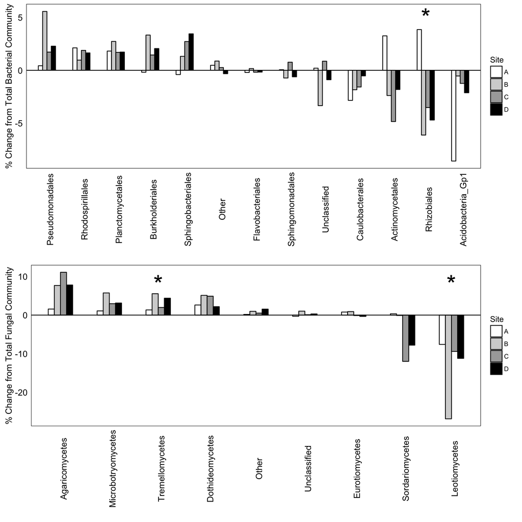

```r
grid.arrange(bact.tax.sites.diff.fig,fungi.tax.sites.diff.fig,ncol=1)
```

**Supplemental Figure S2.** Percent change in relative abundance from the Total community by Sites.

### Reproducibility

```r
# Provide the Session Information for reproducibility
devtools::session_info()
```

```
##  setting  value
##  version  R version 3.2.4 (2016-03-10)
##  system   x86_64, darwin13.4.0
##  ui       X11
##  language (EN)
##  collate  en_US.UTF-8
##  tz       America/Detroit
##  date     2016-05-26
##
##  package    * version date       source
##  chron        2.3-47  2015-06-24 CRAN (R 3.2.0)
##  cluster      2.0.4   2016-04-18 CRAN (R 3.2.5)
##  colorspace   1.2-6   2015-03-11 CRAN (R 3.2.0)
##  data.table * 1.9.6   2015-09-19 CRAN (R 3.2.0)
##  devtools   * 1.11.1  2016-04-21 CRAN (R 3.2.5)
##  digest       0.6.9   2016-01-08 CRAN (R 3.2.3)
##  evaluate     0.8.3   2016-03-05 CRAN (R 3.2.4)
##  formatR      1.3     2016-03-05 CRAN (R 3.2.4)
##  ggplot2    * 2.1.0   2016-03-01 CRAN (R 3.2.4)
##  gridExtra  * 2.2.1   2016-02-29 CRAN (R 3.2.4)
##  gtable       0.2.0   2016-02-26 CRAN (R 3.2.3)
##  htmltools    0.3.5   2016-03-21 CRAN (R 3.2.4)
##  knitr        1.12.3  2016-01-22 CRAN (R 3.2.3)
##  labeling     0.3     2014-08-23 CRAN (R 3.2.0)
##  lattice    * 0.20-33 2015-07-14 CRAN (R 3.2.4)
##  magrittr     1.5     2014-11-22 CRAN (R 3.2.0)
##  MASS         7.3-45  2015-11-10 CRAN (R 3.2.4)
##  Matrix       1.2-5   2016-04-17 CRAN (R 3.2.5)
##  memoise      1.0.0   2016-01-29 CRAN (R 3.2.3)
##  mgcv         1.8-12  2016-03-03 CRAN (R 3.2.4)
##  munsell      0.4.3   2016-02-13 CRAN (R 3.2.3)
##  nlme         3.1-127 2016-04-16 CRAN (R 3.2.5)
##  pander     * 0.6.0   2015-11-23 CRAN (R 3.2.2)
##  permute    * 0.9-0   2016-01-24 CRAN (R 3.2.3)
##  plyr       * 1.8.3   2015-06-12 CRAN (R 3.2.0)
##  Rcpp         0.12.4  2016-03-26 CRAN (R 3.2.4)
##  reshape2   * 1.4.1   2014-12-06 CRAN (R 3.2.0)
##  rmarkdown    0.9.5   2016-02-22 CRAN (R 3.2.3)
##  scales     * 0.4.0   2016-02-26 CRAN (R 3.2.3)
##  stringi      1.0-1   2015-10-22 CRAN (R 3.2.0)
##  stringr      1.0.0   2015-04-30 CRAN (R 3.2.0)
##  vegan      * 2.3-5   2016-04-09 CRAN (R 3.2.4)
##  withr        1.0.1   2016-02-04 CRAN (R 3.2.3)
##  yaml         2.1.13  2014-06-12 CRAN (R 3.2.0)
```